# Demo 2: Public Health & Epidemiology

Merrimack College DSE6630: Healthcare & Life Sciences Analytics

Xin(Vicky) Guo

26 May 2026

# Introduction: Epidemiology of pneumonia-related hospital readmissions

One thing that we largely glossed over as you worked through the hospital readmissions data was that there was actually a strong **spatial component**. Yes, we address state using frequency encoding, but we actually could have chosen to focus more heavily on these spatial components. As data scientists of public health and epidemiology, we likely would not have chosen to ignore it - and in fact one of the **most powerful** tools in our toolkit for analysis are maps.

So, in this demo, we are going to take advantage of the fact that there is a lot of spatial data in the pneumonia-related hospital readmissions dataset that we *could* use: *address*, *county*, *state*, *zip code*… wow! We will first on the **state level** data together and then we will take a more granular look using county-level data. We will also discuss **spatial statistics** we would calculate and even include in our machine learning models if desired!

# 1 State-level Analysis of Pneuomonia-related Hospital Readmissions

## 1.1 Make a base map

Let’s practice bring up a very simple little map of the US from `maps` and `ggplot2`. The `maps` package provides latitude and longitude data for various in the package. The vignette for the package can be found [here](https://cran.r-project.org/web/packages/maps/maps.pdf) if you’d more information on the package. Although we will do something much more complicated for our Project 2, for this little exploration let’s just keep it simple by taking advantage of everything that is pre-loaded in `maps`.

First, we need to extract state-level geographic information using the `map_data()` function. Similar functions exist for other geographic levels of data, including world (country), county, or other regions of the world, but we will be using `state`.

```r
states <- map_data("state")
```

Table 1. The first 6 rows of the states dataframe

| long | lat | group | order | region | subregion |
| --- | --- | --- | --- | --- | --- |
| -87.46201 | 30.38968 | 1 | 1 | alabama | NA |
| -87.48493 | 30.37249 | 1 | 2 | alabama | NA |
| -87.52503 | 30.37249 | 1 | 3 | alabama | NA |
| -87.53076 | 30.33239 | 1 | 4 | alabama | NA |
| -87.57087 | 30.32665 | 1 | 5 | alabama | NA |
| -87.58806 | 30.32665 | 1 | 6 | alabama | NA |

#### The 6 columns in the `states` variables are:

1. `long` = **longitude** in unprojected geographic coordinates (i.e., longitude and latitude on a sphere or ellipsoid like WGS84); ranges from -180 to 180
2. `lat` = **latitude** in unprojected geographic coordinates (i.e., longitude and latitude on a sphere or ellipsoid like WGS84); ranges from -90 to 90
3. `group` = grouping variable for polygon boundaries where all points in a given group represent a single polygon, like parts of a country, state or county. E.g., here Alabama is treated as a single group (labeled as 1 because its the first state alphabetically
4. `order` = indicates the order in which points should be connected to draw the polygon; helps when connecting `long` and `lat` coordinates to ensure the shape is drawn in the correct sequence
5. `region` = represents the primary geographic unit requested, e.g., here, we requested “state” so the region is takes the state names as labels
6. `subregion` = refers to a subdivision within a region, but is only present for detailed maps like “county” not “state”, hence we have no subregion here

#### **Question 1A**: [0.5 points]

Now, let’s make a base map leveraging the `ggplot2` package using the `states` dataset. Notice that `x` will always be longitude, `y` will always be latitude, and that we must also pass it a grouping variable. Why do you think we need the `group` variable here?

**Answer：** The states dataframe stacks all states’ boundary points into one long table. The group aesthetic tells geom_polygon which points belong to the same polygon so each state is drawn and closed as its own shape; without it, ggplot would connect points across different states and produce stray lines.

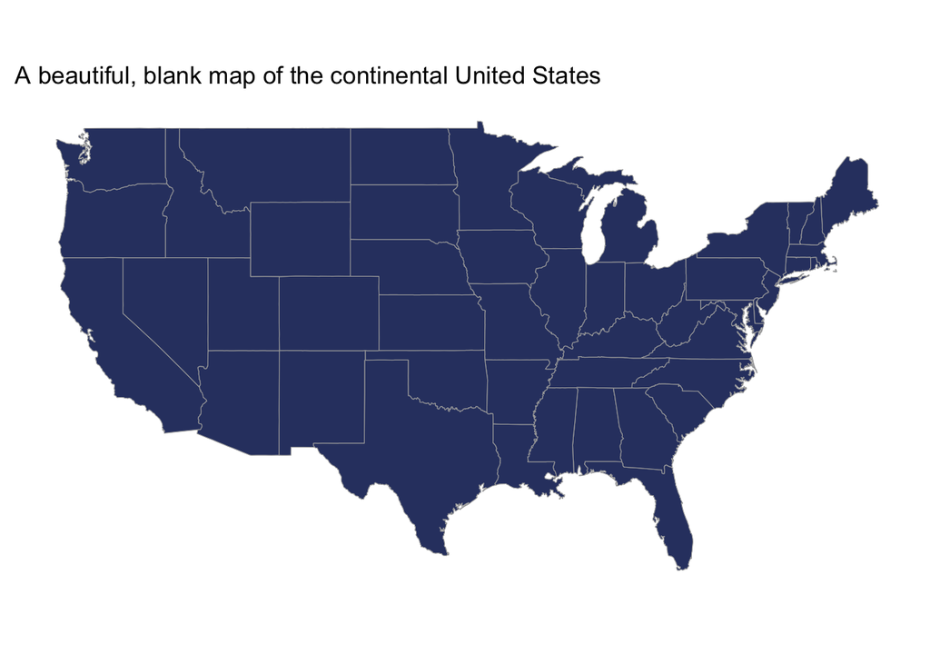

Great, we’ve made our first map of the continental US! It’s pretty uninteresting just as-is, so let’s use this map to overlay our pneumonia-related hospital readmissions data.

## 1.2 Prepare the pneumonia-related hospital readmissions data

### 1.2.1 Bring in the hospital readmissions data

```r
load("pneumoniaFull.Rdata")
## Let's change some key data types as well:
pneumoniaFull <- pneumoniaFull %>%
  mutate_at(c("Score_Death rate for pneumonia patients",
              "Score_Medicare spending per patient",
              "Score_Hospital return days for pneumonia patients"),
            as.numeric)
```

#### **Question 1B**: [0.5 points]

Why didn’t I choose to bring in the fully-processed dataset from Project 1? What does this suggest about our choice of data for spatial analyses versus machine learning models like elastic net?

**Hint**: What information was deleted and/or changes were made downstream that would make those later datasets poor choices for spatial analysis?

**Answer:**

In project 1, the processed dataset have been engineered, 1. State was frequency-encoded (destroying the geographic key needed to join to map polygons) 2. the outcomes were transformed/scaled (destroying interpretable real-world units). 3. Some Rows/Columns may have been dropped or imputed for modeling. in Summary, Project 1 and Demo 2 demand different versions of the data for reach the end goal.

### 1.2.2 Make sure the geographic levels match

Now, take a look at the names of the states in the `states` dataset (from the `region`) column and compare that with the names of the states in our dataset. How do they differ? *You may choose to answer this with code or by otherwise visually inspecting the dataset.*

#### **Question 2A**: [0.25 points]

```r
# Names in the map data
head(sort(unique(states$region)))
```

```
## [1] "alabama"     "arizona"     "arkansas"    "california"  "colorado"
## [6] "connecticut"
```

```r
# Names in our data
head(sort(unique(pneumoniaFull$State)))
```

```
## [1] "AK" "AL" "AR" "AS" "AZ" "CA"
```

**Answer:** The map’s region uses full, lowercase state names (“alabama”); our State column uses two-letter uppercase abbreviations (“AL”). They also don’t cover the same set — our data includes territories (American Samoa AS, etc.) that have no polygon in the continental state map, and the state map omits Alaska and Hawaii.

I am sure you’ve now realized that before we can merge them with the state data that we extracted for the map we must make the state names match. This is because `State` in our pneumonia-related readmissions data is an abbreviation (e.g., “AL”) but it’s the name of the state in the `map_data` (“alabama”). **How can we fix that?**

#### **Question 2B**: [0.75 points]

Explore how you can use the `state.fips` packaged dataset from the `maps` package to do the conversion for you.

Here are the first 6 rows of the the `state.fips` dataset to get you started.

Table 2. The first 6 rows of the state.fips dataframe

| fips | ssa | region | division | abb | polyname |
| --- | --- | --- | --- | --- | --- |
| 1 | 1 | 3 | 6 | AL | alabama |
| 4 | 3 | 4 | 8 | AZ | arizona |
| 5 | 4 | 3 | 7 | AR | arkansas |
| 6 | 5 | 4 | 9 | CA | california |
| 8 | 6 | 4 | 8 | CO | colorado |
| 9 | 7 | 1 | 1 | CT | connecticut |

Now, write code that would allow you to replace the two-letter abbreviation for `State` in the `pneumoniaFull` dataset with the full-name of the state in `states$region` to allow merging.

```r
library(maps)
data(state.fips)


# A join-based conversion:
pneumoniaFull <- pneumoniaFull %>%
  left_join(state.fips %>% select(abb, polyname),
            by = c("State" = "abb"))
```

Sadly, sometimes this can fall short. For example, take a look at the state of Washington:

Table 3. The state.fips dataframe for just Washington state

| fips | ssa | region | division | abb | polyname |
| --- | --- | --- | --- | --- | --- |
| 53 | 50 | 4 | 9 | WA | washington:san juan island |
| 53 | 50 | 4 | 9 | WA | washington:lopez island |
| 53 | 50 | 4 | 9 | WA | washington:orcas island |
| 53 | 50 | 4 | 9 | WA | washington:whidbey island |
| 53 | 50 | 4 | 9 | WA | washington:main |

States with islands, like WA state or NY, can have additional mappings that we’d miss if we weren’t aware of this issue.

#### **Question 3**: [1 point]

What could we do to `state.fips` to fix this problem? Would your solution become tedious if, for example, we were doing counties instead?

```r
state.fips_clean <- state.fips %>%
  mutate(region = sub(":.*", "", polyname)) %>%   # drop ":whidbey island"
  distinct(abb, region)                            # one row per state

state.fips_clean
```

```
##    abb               region
## 1   AL              alabama
## 2   AZ              arizona
## 3   AR             arkansas
## 4   CA           california
## 5   CO             colorado
## 6   CT          connecticut
## 7   DE             delaware
## 8   DC district of columbia
## 9   FL              florida
## 10  GA              georgia
## 11  ID                idaho
## 12  IL             illinois
## 13  IN              indiana
## 14  IA                 iowa
```

[output cut: 35 more lines]

**Answer:** Yes — there are only ~50 states but ~3,100+ counties, and many coastal/island counties have multiple sub-polygons, plus duplicate county names across states (e.g., “Washington County” exists in ~30 states). The cleanup and disambiguation would balloon, which is exactly why FIPS codes (unique numeric IDs) become essential at the county level.

An alternative solution (and not the only one by any means) could be to write a function to do the mapping ourselves. It’s easier in this particular case to write our own little function, I think. Notice also that I am choosing to name the new column in `pneumoniaFull.Rdata` as `region`; this is to match the column name in the `states` dataframe that we use for mapping so we can merge the tables more easily.

```r
## Use this to see which states we have in our dataset, if needed
# unique(states$region)

## Set up a lookup table that goes abbr = state_name
stateNames <- c(
  "AL" = "alabama", "AK" = "alaska", "AZ" = "arizona", "AR" = "arkansas",
  "CA" = "california", "CO" = "colorado", "CT" = "connecticut",
  "DC" = "district of columbia", "DE" = "delaware", "FL" = "florida",
  "GA" = "georgia", "HI" = "hawaii", "ID" = "idaho", "IL" = "illinois",
  "IN" = "indiana", "IA" = "iowa", "KS" = "kansas", "KY" = "kentucky",
  "LA" = "louisiana", "ME" = "maine", "MD" = "maryland", "MA" = "massachusetts",
  "MI" = "michigan", "MN" = "minnesota", "MS" = "mississippi", "MO" = "missouri",
  "MT" = "montana", "NE" = "nebraska", "NV" = "nevada", "NH" = "new hampshire",
  "NJ" = "new jersey", "NM" = "new mexico", "NY" = "new york",
  "NC" = "north carolina", "ND" = "north dakota", "OH" = "ohio",
  "OK" = "oklahoma", "OR" = "oregon", "PA" = "pennsylvania",
  "RI" = "rhode island", "SC" = "south carolina", "SD" = "south dakota",
  "TN" = "tennessee", "TX" = "texas", "UT" = "utah", "VT" = "vermont",
  "VA" = "virginia", "WA" = "washington", "WV" = "west virginia",
  "WI" = "wisconsin", "WY" = "wyoming")

## Function to look up the state name based on abbreviation
getStateName <- function(abbr) {
  stateNames[abbr]
}
```

#### **Question 4**: [1 point]

Show that you understand how the `getStateName` works by using it to replace the abbreviation with the statename into a new column you call `feature` in the `pneumoniaFull` dataframe.

**HINT**: You can use the `mutate()` function or you could just use the base `R` way, either one!

```r
# Below using region instead of feature, so I create new column region.

# Old way
# pneumoniaFull <- pneumoniaFull %>%
#   mutate(region = getStateName(State))

pneumoniaFull$region<- getStateName(pneumoniaFull$State)
```

### 1.2.3 Aggregate `PredictedReadmissionsRate` by state

Now, before we add the pneumonia-related hospital readmissions to the map, we need to **aggregate** it at the state-level. We will want to do that by aggregating across states and taking the `mean()` and `median()`.

#### **Question 5**: [1 point]

Start from my code and finish the aggregation by state for the `mean()` and `median()` by filling in the blanks. Notice that we are making a separate dataset called `stateAggPneumonia`. Make sure to uncomment the code when you’re ready to run it.

```r
stateAggPneumonia <- pneumoniaFull %>%
    ## Grab readmissions and region
    select(PredictedReadmissionRate, region,
          `Score_Death rate for pneumonia patients`,
          `Score_Hospital return days for pneumonia patients`,
          `Score_Medicare spending per patient`) %>%
   ## Change region to a factor
   mutate(region = as.factor(region)) %>%
   ## Change any other columns from character to numeric
   mutate_if(is.character, as.numeric) %>%
   ## Group by region
   group_by(region) %>%
   ## Create the new aggregated variables for each measure
   summarize(meanReadmissions = mean(PredictedReadmissionRate, na.rm = TRUE),
             medianReadmissions = median(PredictedReadmissionRate, na.rm = TRUE),
             meanDeathRate = mean(`Score_Death rate for pneumonia patients`,
               na.rm = TRUE),
             medianDeathRate = median(`Score_Death rate for pneumonia patients`,
               na.rm = TRUE),
             meanHospitalReturnDays = mean(`Score_Hospital return days for pneumonia patients`, na.rm = TRUE),
             medianHospitalReturnDays = median(`Score_Hospital return days for pneumonia patients`, na.rm = TRUE),
             meanMedicareSpending = mean(`Score_Medicare spending per patient`, na.rm = TRUE),
             medianMedicareSpending = median(`Score_Medicare spending per patient`, na.rm = TRUE)) %>%

   ## Remove the missing region
   filter(!is.na(region))
```

### 1.2.4 If you were not able to figure it out, load the state-level aggregated data set

```r
load(file = "stateAggPneumonia.Rdata")
```

#### **Question 6**: [1 point]

Are there any missing data? If so, what data are missing? Did you make a mistake?

```r
colSums(is.na(stateAggPneumonia))
```

```
##                   region         meanReadmissions       medianReadmissions
##                        0                        0                        0
##            meanDeathRate          medianDeathRate   meanHospitalReturnDays
##                        0                        0                        0
## medianHospitalReturnDays     meanMedicareSpending   medianMedicareSpending
##                        0                        1                        1
```

**Answer:** Yes, there is one missing value, both meanMedicareSpending and medianMedicareSpending are missing (NaN) for a single state. It tell us more likely the Medicare spending score has the most missing values in the raw data, and for this one state none of its hospitals reported a value, so there was nothing for mean/median to summarize even with na.rm = TRUE. It’s normaly in real world data sets to have missing value, there is no mistake in data.

### 1.2.5 Means or medians? How do you choose?

Choosing the mean or median value here is going to be really important for anyone interpreting our maps, as well as spatial statistics we will calculate downstream. Recall that we can choose the **mean** when:

- The data is symmetric (i.e., it is approximately normal or has that beautiful bell-shaped curve!)
- There are no extreme outliers or heavy skew
- You are working with data that were measured on a *truly continuous scale* (i.e., height, weight) OR can be approximated by a normal distribution because of a sufficiently large sample size (see the [Central Limit Theorem](https://math.mit.edu/~dav/05.dir/class6-prep.pdf))
- You want to describe an “average”
- You are using statistical methods that assume normality (i.e., **parametric** tests)

On the other hand, we will choose the **median** when:

- The data are skewed (i.e., there us long tail on one side of the curve) OR the data are lepto- or platykurtic (overly “peaked” or flattened, respectively)
- **Skewness** Guidelines:
  - Skewness > 0 $\rightarrow$ right-skewed $\rightarrow$ prefer **median**
  - Skewness $\approx$ 0 $\rightarrow$ symmetric $\rightarrow$ prefer **mean**
  - Skewness < 0 $\rightarrow$ left-skewed $\rightarrow$ prefer **median**
- **Kurtosis** Guidelines:
  - Kurtosis > 3 $\rightarrow$ Leptokurtic (sharp peak, heavy tails) $\rightarrow$ prefer **median**
  - Kurtosis $\approx$ 3 $\rightarrow$ Mesokurtic (bell-shaped) $\rightarrow$ prefer **mean**
  - Kurtosis < 3 $\rightarrow$ Platykurtic (flat peak, light tails) $\rightarrow$ prefer **median**
- There are outliers that could distort the mean
- You want to describe the “typical value” or “middle case”
- You have ordinal data (e.g., patient satisfaction ratings)
- You are using **non-parametric** statistical methods that do not assume normality because you found that your data were not normally distributed

#### **Question 7**: [1 point]

You may have to do some research if you do not recall, but why would showing someone a mean when we should have showed them a median, or vice versa, potentially create interpretation problems for us or our stakeholders?

**Answer:** I think core concept is the mean and median answer different questions, and on skewed data they diverge. Let’s imagine reporting the mean readmission rate for a state where a few large urban hospitals have very high rates. The mean would overstate what a “typical” hospital looks like, and a policymaker might wrongly conclude the whole state is performing poorly and divert resources, when really most hospitals are fine and a handful are outliers. Conversely, reporting a median when the data are genuinely symmetric throws away information and can understate the impact of those high-cost tail hospitals (which matter enormously for budgeting). Either way you mislead the audience about where the “center” actually sits and what action to take.

Choosing the statistic that matches the distribution’s shape keeps the interpretation honest.

#### 1.2.5.1 Using boxplots embedded in violin plots to assess distribution symmetry

#### **Question 8A**: [1 points]

Practice reading boxplots to decide, for each measure, whether you should use the mean or median, or whether it matters. Need some help with boxplots? This [article](https://www.labxchange.org/library/items/lb:LabXchange:d8863c77:html:1) breaks it down nicely.

**Based on Figure 1 below**, which measure(s) do you think would benefit from the median over the mean? Why?

**Answer:**

After reading all the violins and boxplots generated, all four measures are right-skewed with different level. in each panel the mass of the violin sits in the lower-middle with a long, thin tail of outlier points stretching upward, Pneumonia Hospital Return Days which is most skewed by far – the median sits low in the box and the outliers stretch way up past 100 even though most hospitals cluster down near 0-20. Pneumonia Readmission Rate and Pneumonia Medicare Spending show clear-to-moderate right skew, also has noticeable heavy tails on both ends. Pneumonia Death Rate is the closest to symmetric, but it still leans right a little.

Since none of these are a clean symmetric bell shape, all four would be better summarized with the median than the mean — and Hospital Return Days especially.

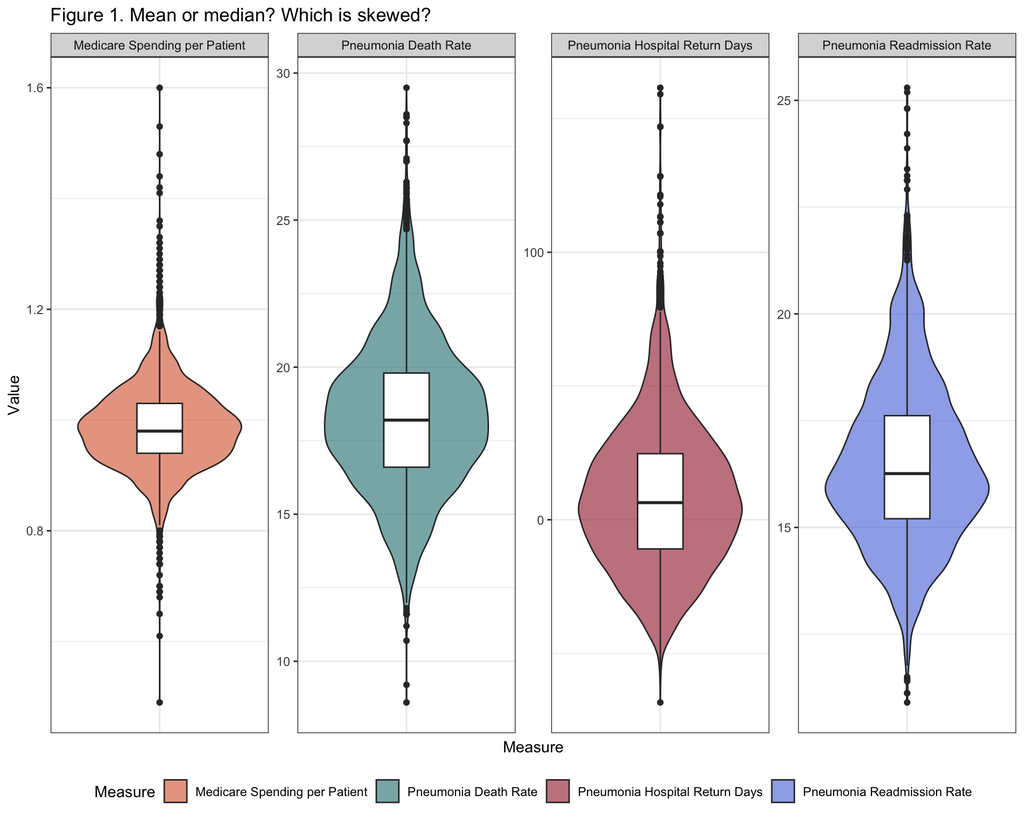

Figure 1. Violin and boxplots to assess distribution symmetry

#### 1.2.5.2 D’Agostino’s $K^2$ Skewness Test to assess distribution symmetry

In Project 1, I introduced the Shapiro-Wilk test for normality for those who were not familiar with it. As a reminder, the Shapiro-Wilk test is a goodness-of-fit test to assess whether an approximately normal transformation matches our data, with the null hypothesis that it does. It does this by computing a $W$ statistic compares ordered sample values to the corresponding normal distribution quantiles. As I mentioned before, it typically has high power to detect deviations from normality in most situations unless $N>5000$.

But normality tests (and Shapiro-Wilk is not the only one!) is not a sufficient test of **skewness** or **kurtosis**. E.g., we can have enough skew or kurtosis that our distribution would be better described by a median over a mean, yet it does not deviate at the 5% significance threshold from a normal approximation! In other words, it can look normal, not deviate from normal per a Shapiro-Wilk test, and *yet* still be sufficiently skewed that the median is a better choice. One reason this can happen, for example, is if you have a lot of repeats of the same value, as seen in count data or some quantitative measures that have been rounded to integers.

**Enter [D’Agostino’s $K^2$ or Skewness Test](https://en.wikipedia.org/wiki/D%27Agostino%27s_K-squared_test).** Also sometimes referred to as the “D’Agostino-Pearson Test” in some statistics sources, the D’Agostino test was also designed as a goodness-of-fit test for distribution departures from normality. However, it simply doesn’t perform quite as well overall as a Shapiro-Wilk for tests of deviation from normality BUT it is superior for assessing differences in skewness or kurtosis! What the test does is computes two components, (1) *Skewness* to check for asymmetry and (2) *Kurtosis* to check for peakedness or flatness, and combines these components into a $K^2$ test statistic, a version of the $\chi^2$ statistic.

Let’s use the `agostino.test()` from the `moments` package to apply this to our data. For our first example, I will use `PredictedReadmissionRate`. Remember, the null hypothesis, $H_0$, is that there is **no** skew. So, a $p < 0.05$ means we **reject the null hypothesis of symmetry** and conclude that the data are significantly skewed. However, is $p \ge 0.05$, then there is no significant skewness to the data.

```r
agostino.test(pneumoniaFull$PredictedReadmissionRate)
```

```
##
##  D'Agostino skewness test
##
## data:  pneumoniaFull$PredictedReadmissionRate
## skew = 0.53869, z = 12.68091, p-value < 0.00000000000000022
## alternative hypothesis: data have a skewness
```

*Interpretation*: Because $p<0.05$, we reject the hypothesis of symmetry and conclude that predicted readmissions are **significantly skewed**. We should use the median to aggregate this variable.

#### **Question 8B**: [1 point]

Your task is to repeat this test, with interpretations, for `Score_Death rate for pneumonia patients`, `Score_Hospital return days for pneumonia patients`, and `Score_Medicare spending per patient`:

```r
agostino.test(pneumoniaFull$`Score_Death rate for pneumonia patients`)
```

```
##
##  D'Agostino skewness test
##
## data:  pneumoniaFull$`Score_Death rate for pneumonia patients`
## skew = 0.29664, z = 8.14876, p-value = 0.0000000000000003677
## alternative hypothesis: data have a skewness
```

```r
agostino.test(pneumoniaFull$`Score_Hospital return days for pneumonia patients`)
```

```
##
##  D'Agostino skewness test
##
## data:  pneumoniaFull$`Score_Hospital return days for pneumonia patients`
## skew = 0.73702, z = 18.56861, p-value < 0.00000000000000022
## alternative hypothesis: data have a skewness
```

```r
agostino.test(pneumoniaFull$`Score_Medicare spending per patient`)
```

```
##
##  D'Agostino skewness test
##
## data:  pneumoniaFull$`Score_Medicare spending per patient`
## skew = 0.60876, z = 14.68087, p-value < 0.00000000000000022
## alternative hypothesis: data have a skewness
```

#### 1.2.5.3 Assessing stability of central tendency estimates

One final thing we can do is assess the stability of the estimates of central tendency we’ve calculated, the **mean** and the **median** to ensure that, post-aggregation, we don’t see any issues in the resulting distribution. If we did, we would want to consider another estimate we haven’t yet explored - e.g., another percentile or even a weighted-mean.

#### **Question 8C**: [1 points]

**Based on Figure 2 below**, and using your choices from questions 8A and 8B, assess the **stability** (i.e., symmetry) of the estimates you selected as the best (either mean or median) for each of the four variables. Do you see any cause for concern with your choice, or do you feel comfortable to proceed with what you’ve selected?

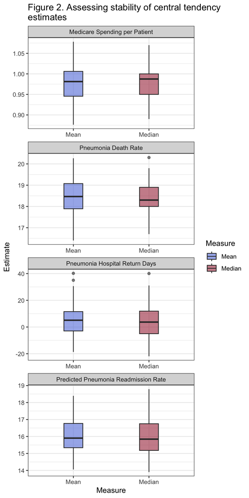

Figure 2. Compare stability of mean vs. median after aggregation

#### 1.2.5.4 Final selection of mean vs. median

The time has come to make your final selection! Your job is to **remove** the columns from `stateAggPneumonia` that do not correspond with your final decisions of mean or median for questions 8A-C.

#### **Question 8D**: [1 points]

```r
stateAggPneumonia <- stateAggPneumonia %>%
  select(-meanReadmissions,
         -meanDeathRate,
         -meanHospitalReturnDays,
         -meanMedicareSpending)
```

### 1.3 Merge `stateAggPneumonia` with the `states` data for mapping.

Let’s use a `left_join` on `stateAggPneumonia` on the `states` dataframe we made in Section 1. **Make sure to join by the shared geographic identifier**; here that is `region`.

```r
mergedStateAggPneumonia <- left_join(stateAggPneumonia, states, by = "region")
```

### 1.4 Chloropeth map: predicted pneumonia readmissions

Recall from lecture that a choropleth map is a type of thematic map where areas (such as states, counties, or other geographic regions) are shaded or colored in relative proportion to the quantative value of a variable.

What follows is code to perform chloropeth mapping in `ggplot2` building on our base map from Section 1. I will show you how to do the first one for **median** Predicted Readmission Rate. You will be mapping the subsequent variables based on your choices of mean or median!

**NOTE**: At this stage, you will get an error if you did NOT choose to retain `medianReadmissions`! If you made that mistake, return to this step!

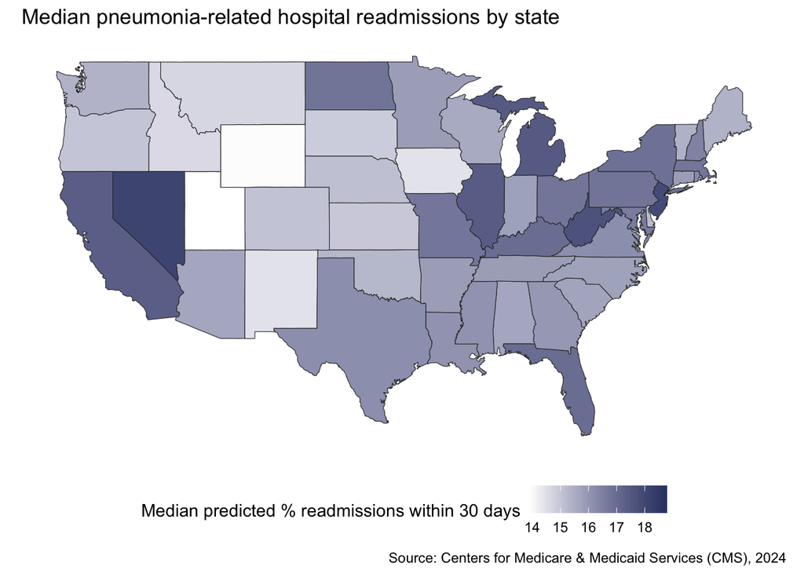

#### **Question 9A**: [0.25 points]

Do you notice any trends that could be worth testing? If you’re not sure, take a look at this sorted table showing the top 10 states for median pneumonia-related hospital readmissions:

**Answer:** Looking at the top-10 states, a few possible shared traits stand out that could be worth testing: several are densely populated, urbanized states (e.g., in the Northeast), which could mean more facilities and faster spread; some have notably elderly populations; and others are higher-poverty states. Any of these — population density, proportion elderly — could be a testable hypothesis for why readmissions cluster the way they do.

Table 4. Top 10 states for pneumonia-related readmissions.

| Region | Median Predicted Pneumonia Readmissions |
| --- | --- |
| district of columbia | 18.79 |
| nevada | 18.10 |
| new jersey | 17.91 |
| west virginia | 17.71 |
| michigan | 17.46 |
| illinois | 17.40 |
| california | 17.35 |
| florida | 16.99 |
| kentucky | 16.98 |
| new york | 16.88 |

**HINT**: It may not be readily obvious from the map or table! If you don’t see a hypothesis, that’s okay. But try to think about anything some of these states might have in common, if anything.

#### **Question 9B**: [1.75 points]

Your task is to now update the code I used to make `p1` for the remaining three variables. I suggest copying the code and following the comments to update everywhere I have `!!Update` written. You should update per the following specification for **full credit**:

- `Pneumonia Death Rate` (whether mean or median, your choice from earlier) $\rightarrow$ color should be `skittles[3]`
  - Don’t forget to update the axis labels and titles appropriately. Death rate was measured as number of deaths per pneumonia cases in 30 days.

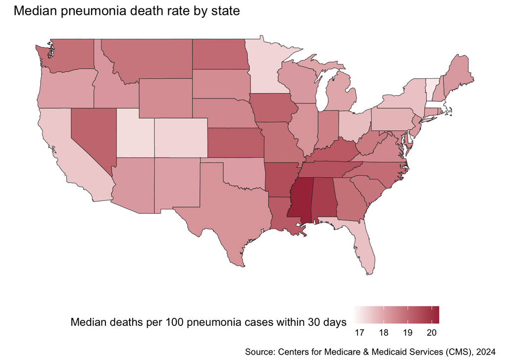

```r
## Store the plot into a variable called p1
p_death <- ggplot(mergedStateAggPneumonia, aes(x = long, y = lat, group = group,
                               ## !!Update the fill to the variable you want
                               fill = medianDeathRate)) +
  geom_polygon(color = "grey20", size = 0.2, alpha = 1) +
  scale_fill_continuous(name="Median deaths per 100 pneumonia cases within 30 days",
            low = "white", high = skittles[3]) +
            ## Leave low as white; only !!update high!

  labs(title = "Median pneumonia death rate by state",
   ## Leave the caption as-is
   caption = "Source: Centers for Medicare & Medicaid Services (CMS), 2024") +

  ## -- This makes the map pretty. No need to change any of this -- ##
  ## Makes a completely blank map background
  theme(
    panel.grid = element_blank(),
    panel.background = element_rect(fill = "white"),
    plot.background = element_rect(fill = "white"),
    axis.text = element_blank(),
    axis.ticks = element_blank(),
    axis.title = element_blank(),
    legend.position = "bottom"
  ) +
  ## Sets the aspect ratio to roughly match US map proportions
  coord_fixed(1.3)

## Displays the map
p_death
```

- `Medicare Spending` (whether mean or median, your choice from earlier) $\rightarrow$ color should be `skittles[7]`
  - Don’t forget to update the axis labels and titles appropriately. Medicare spending was measured at each hospital per patient.

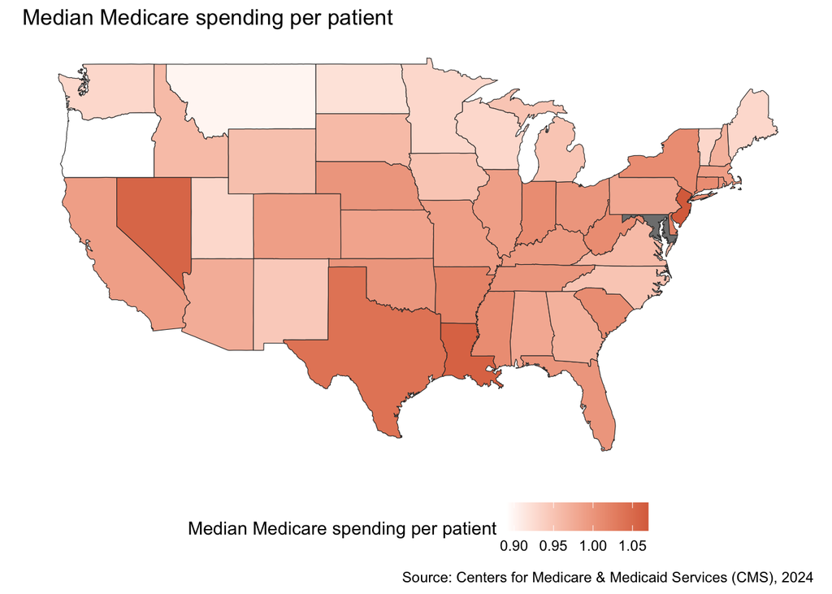

```r
## Store the plot into a variable called p1
p_spend <- ggplot(mergedStateAggPneumonia, aes(x = long, y = lat, group = group,
                               ## !!Update the fill to the variable you want
                               fill = medianMedicareSpending)) +
  geom_polygon(color = "grey20", size = 0.2, alpha = 1) +
  scale_fill_continuous(name="Median Medicare spending per patient",
            low = "white", high = skittles[7]) +
            ## Leave low as white; only !!update high!

  labs(title = "Median Medicare spending per patient",
   ## Leave the caption as-is
   caption = "Source: Centers for Medicare & Medicaid Services (CMS), 2024") +

  ## -- This makes the map pretty. No need to change any of this -- ##
  ## Makes a completely blank map background
  theme(
    panel.grid = element_blank(),
    panel.background = element_rect(fill = "white"),
    plot.background = element_rect(fill = "white"),
    axis.text = element_blank(),
    axis.ticks = element_blank(),
    axis.title = element_blank(),
    legend.position = "bottom"
  ) +
  ## Sets the aspect ratio to roughly match US map proportions
  coord_fixed(1.3)

## Displays the map
p_spend
```

- `Pneumonia Hospital Return Days` (whether mean or median, your choice from earlier) $\rightarrow$ color should be `skittles[5]` - Don’t forget to update the axis labels and titles appropriately. Hospital return days are the number of days readmitted pneumonia patients spend in the hospital. Readmissions are only measured within 30 days of the original admission to the hospital for pneumonia.

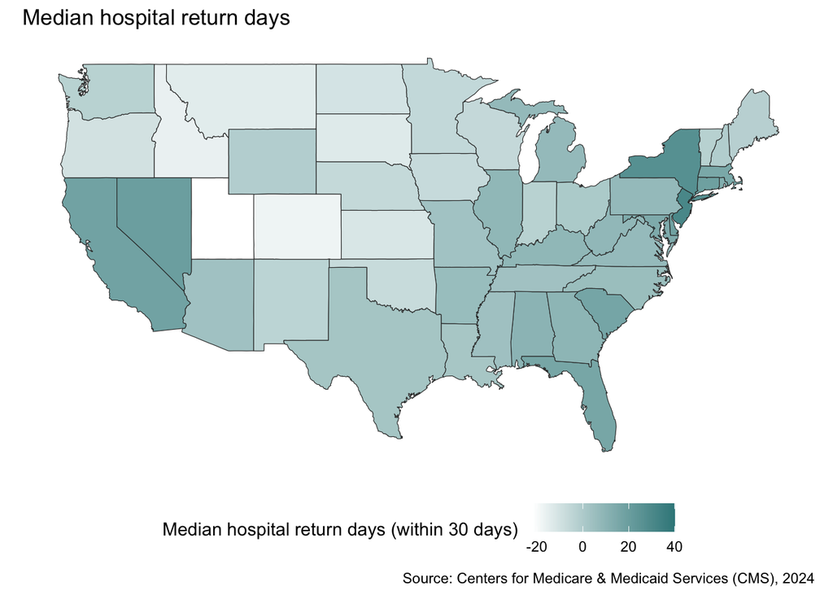

```r
## Store the plot into a variable called p1
p_return <- ggplot(mergedStateAggPneumonia, aes(x = long, y = lat, group = group,
                               ## !!Update the fill to the variable you want
                               fill = medianHospitalReturnDays)) +
  geom_polygon(color = "grey20", size = 0.2, alpha = 1) +
  scale_fill_continuous(name="Median hospital return days (within 30 days) ",
            low = "white", high = skittles[5]) +
            ## Leave low as white; only !!update high!

  labs(title = "Median hospital return days",
   ## Leave the caption as-is
   caption = "Source: Centers for Medicare & Medicaid Services (CMS), 2024") +

  ## -- This makes the map pretty. No need to change any of this -- ##
  ## Makes a completely blank map background
  theme(
    panel.grid = element_blank(),
    panel.background = element_rect(fill = "white"),
    plot.background = element_rect(fill = "white"),
    axis.text = element_blank(),
    axis.ticks = element_blank(),
    axis.title = element_blank(),
    legend.position = "bottom"
  ) +
  ## Sets the aspect ratio to roughly match US map proportions
  coord_fixed(1.3)

## Displays the map
p_return
```

# 2 State-level Spatial Analysis

To perform spatial analysis, one needs geographic-level aggregate data that has been joined with geometry. Although it might feel like we technically have everything we need, alas, we do not - quite. Remember that our ultimate goal for our stakeholder is **prediction** - so what this means is that we need to determine whether spatial structure is a problem before we proceed with predictions. If it is, we can include spatially lagged variables in our analysis; if not, we can proceed with exactly what we pre-processed in Project 1.

## 2.1 Spatial Analysis Pre-processing Steps

### 2.1.1 Identify your appropriate method of aggregation for each variable, but **especially** your outcome of interest!

But because our ultimate goal is to try to tie this back with all of the work we did in Project 1, I will actually give you data, which you get by running this code chunk. This returns both the training and testing sets, aggregated but not yet merged with geometries, so we don’t lose our other encoding and especially our transformations for OLS. They are going to be called `stateAggTrain` and `stateAggTest`, respectively.

```r
# I have to update this file to fix errors to move forward.
source(file = "loadTrainTest.R")

exists("stateAggTrain")             # should be TRUE
```

```
## [1] TRUE
```

```r
sort(unique(stateAggTrain$region))  # should show the regions
```

```
##  [1] "alabama"              "alaska"               "arizona"
##  [4] "arkansas"             "california"           "colorado"
##  [7] "connecticut"          "delaware"             "district of columbia"
## [10] "florida"              "georgia"              "hawaii"
## [13] "idaho"                "illinois"             "indiana"
## [16] "iowa"                 "kansas"               "kentucky"
## [19] "louisiana"            "maine"                "maryland"
## [22] "massachusetts"        "michigan"             "minnesota"
## [25] "mississippi"          "missouri"             "montana"
## [28] "nebraska"             "nevada"               "new hampshire"
## [31] "new jersey"           "new mexico"           "new york"
## [34] "north carolina"       "north dakota"         "ohio"
## [37] "oklahoma"             "oregon"               "pennsylvania"
## [40] "rhode island"         "south carolina"       "south dakota"
## [43] "tennessee"            "texas"                "utah"
## [46] "vermont"              "virginia"             "washington"
## [49] "west virginia"        "wisconsin"            "wyoming"
```

```r
n_distinct(stateAggTrain$region)    # looking for 52
```

```
## [1] 52
```

**NOTE 1** that these new aggregated training and testing states have `region` in them instead of `state`. This is so that they are already cleaned up for merging with geometries.

**NOTE 2**: All of the raw variables have been named `Median_Raw...` to distinguish them from their transformed and scaled counterparts!

#### **Question 10A**: [0.25 points]

Check that all of the states (in `region`) made it into the training set. If you choose to do this by counting, say with `unique()` or `distinct()`, you should get **52** if they are all present.

```r
sort(unique(stateAggTrain$region))
```

```
##  [1] "alabama"              "alaska"               "arizona"
##  [4] "arkansas"             "california"           "colorado"
##  [7] "connecticut"          "delaware"             "district of columbia"
## [10] "florida"              "georgia"              "hawaii"
## [13] "idaho"                "illinois"             "indiana"
## [16] "iowa"                 "kansas"               "kentucky"
## [19] "louisiana"            "maine"                "maryland"
## [22] "massachusetts"        "michigan"             "minnesota"
## [25] "mississippi"          "missouri"             "montana"
## [28] "nebraska"             "nevada"               "new hampshire"
## [31] "new jersey"           "new mexico"           "new york"
## [34] "north carolina"       "north dakota"         "ohio"
## [37] "oklahoma"             "oregon"               "pennsylvania"
## [40] "rhode island"         "south carolina"       "south dakota"
## [43] "tennessee"            "texas"                "utah"
## [46] "vermont"              "virginia"             "washington"
## [49] "west virginia"        "wisconsin"            "wyoming"
```

#### **Question 10B**: [0.25 points]

Why am I not asking you to check the states in the testing data?

**Answer:** The train/test split was done randomly by hospital. The training set is the big chunk, so basically every state shows up there — that’s worth confirming. The test set is the small leftover, and a state with only a couple of hospitals could randomly end up with zero in the test set, which is expected, not a bug. Plus we’re supposed to leave the test set alone until final evaluation, so there’s no reason to check it now.

#### **Question 10C**: [0.25 points]

In the aggregation that I did for both `stateAggTrain` and `stateAggTest` I took the **median** for everything. Why, when we just went through all the rigmarole of figuring out if we should display the mean or the median of variables like Predicted Pneumonia Readmissions?

**HINT 1**: What have we already done to the training and testing sets that we had not done here because we went back to the raw data?

**HINT 2**: Why is a median *or* a mean acceptable if we’re working with scaled and centered data?

**Answer:** These are the Project 1 sets, which were already Box-Cox transformed, centered, and scaled. In Section 1 we went back to the raw data, which still had skew, so picking mean vs. median actually mattered. Here the transformation already made the distributions roughly symmetric, and when data are symmetric the mean and median are basically the same — so either works， The median is just a safe default.

### 2.1.2 Identify your geographic level of aggregation for each variable.

**Here, we have selected state**. We already decided this going into the previous analysis; it only makes sense to continue that level of spatial analysis first.

### 2.1.3 Get the right geometries for spatial analysis.

Sadly, what we used for mapping will not be sufficient. Recall that, in lecture, I kept referring to something called **shapefiles** and I said we wouldn’t have to worry about them a ton (yet) but that we were going to need them already. Well, here they are!

A shapefile is a widely used geospatial vector data format for geographic information system (GIS) software, storing the location, shape, and attributes of geographic features such as points, lines, and polygons. This is is typically across a set of related files with file extensions of `.shp`, `.shx`, or `.dbf`. Because **shapefiles are the gold-standard** of spatial analysis, our spatial statistics packages in R similarly expect geometrics in **shapefile** (often abbreviates as **sf**) format. We could either import shapefiles (which we will do in Project 2) or, here, we will simply convert the geometrics from the `maps` package into shapefile format so we can calculate our spatial statistics.

Complicated, right? Thankfully, most of that magic will be performed for us using the `sf` package in R. If you want to learn more about the `sf` package, you can find that [here](https://r-spatial.github.io/sf/).

*We can convert to shapefile format in a single line of code:*

```r
## Get state map geometries in shapefile format
states_sf <- st_as_sf(map("state", plot = FALSE, fill = TRUE))
```

#### **Question 10D**: [0.25 points]

You may need to do a little digging, but what exactly is the `st_as_sf()` function from the `sf` package doing? Can you figure out why I didn’t just use the `states` object we already used for mapping?

```r
states_sf
```

```
## Simple feature collection with 49 features and 1 field
## Geometry type: MULTIPOLYGON
## Dimension:     XY
## Bounding box:  xmin: -124.6813 ymin: 25.12993 xmax: -67.00742 ymax: 49.38323
## Geodetic CRS:  +proj=longlat +ellps=clrk66 +no_defs +type=crs
## First 10 features:
##                                        ID                           geom
## alabama                           alabama MULTIPOLYGON (((-87.46201 3...
## arizona                           arizona MULTIPOLYGON (((-114.6374 3...
## arkansas                         arkansas MULTIPOLYGON (((-94.05103 3...
## california                     california MULTIPOLYGON (((-120.006 42...
## colorado                         colorado MULTIPOLYGON (((-102.0552 4...
## connecticut                   connecticut MULTIPOLYGON (((-73.49902 4...
## delaware                         delaware MULTIPOLYGON (((-75.80231 3...
## district of columbia district of columbia MULTIPOLYGON (((-77.13731 3...
## florida                           florida MULTIPOLYGON (((-85.01548 3...
## georgia                           georgia MULTIPOLYGON (((-80.89018 3...
```

**Answer:** st_as_sf() converts spatial data into an sf (simple features) object — a shapefile-format dataframe where each row is one state and its full polygon is stored in a geometry column, along with a coordinate reference system (CRS). We can’t reuse the old states object because it came from map_data(): each row is just a single lat/long point, with states held together by group/order.

### 2.1.4 Calculate spatial weights for our target, predicted pneumonia readmission rate.

Now, we finally get to the meat of it! **Spatial weights** represent the spatial relationships (or influence) between geographic units (here, states). In other words, spatial weights define how much nearby observations contribute to calculations for a given location. These weights are typically based on proximity, contiguity (shared borders), or distance, but it depends on the type of spatial autocorrelation or dependence in the data.

Recall that, in lecture, I mentioned that we were going to look at spatial autocorrelation. Spatial autocorrelation is the relative degree to which the value of a variable (e.g., hospital readmissions) at one location is similar to values at nearby locations. When nearby areas have similar values (e.g., high readmission rates clustered together), it’s called *positive* spatial autocorrelation (**clustering**); when nearby areas have very different values, it’s *negative* spatial autocorrelation (**dispersal**). Thus, you can think of **spatial weights** as measures of the spatial correlation in hospital readmissions between states, in our case!

We will use a package called spatial dependence (`spdep`, more information [here](https://r-spatial.github.io/spdep/index.html)) to calculate our spatial weights. We have a series of small sub-steps to go through to get there.

#### 2.1.4.1 Turn off S2 geometry engine, if needed (usually a good idea if you didn’t import shapefiles directly or if they are older shapefiles)

By default, the `sf` package now uses Google’s S2 geometry engine (a library for geometric calculations on the sphere developed by Google for their maps), which is strict and throws errors when geometries are even slightly invalid (like if edges should cross each other even slightly). We will choose to turn off the S2 engine just for this step because it will fail otherwise. This is often going to be the case _when you are not importing shapefiles directly or if your shapefiles are older and predate the S2 engine__. But, we will turn it back on when we’re done.

*We can disable the S2 engine like this:*

```r
## Disable Google S2 engine
sf_use_s2(FALSE)
```

We will also just do a quick cleanup using the `st_make_valid` function **just to be safe**. It never hurts! All it does is clean up any of those cases where the borders do cross (i.e., are invalid) so we don’t get any errors.

*We can validate the geometry edges like this:*

```r
## Clean up the edges of `states_sf` to be safe
states_sf <- st_make_valid(states_sf)
```

**Find Neighboring States**

Next, we will use the `poly2nb()` function from the `spdep` package to create a *neighborhood list* based on the polygon boundaries of our spatial objects (states). It is using the shapefile (sf) object we already made, `states_sf`, to do this. What it will do is defines which polygons (states) are neighbors by looking for which ones share borders with each other (called **contiguity**). By default, it uses what is called “queen” continuity (derived from chess); it would define a neighboring state as one that shares any point (edge OR corner) as neighbors.

As an example, Colorado and Arizona do not share a border only a corner, right? But according to “queen” contiguity, they are still neighbors.

#### **Question 11A**: [0.5 points]

Look up “rook” continuity and explain what (1) what it means, (2) how the neighbor relationship of Colorado and Arizona would change, if it would, and (3) how we change to this type of contiguity in the `poly2nb()` function. (You don’t need to actually change it in the code, however.)

**Answer:**

Rook contiguity defines two areas as neighbors only if they share a border edge, not merely a corner — analogous to a rook in chess moving only in straight lines. Under rook contiguity, Colorado and Arizona would no longer be neighbors, because they meet only at the Four Corners point (a shared corner), which queen contiguity counts but rook does not. To use rook contiguity, set queen = FALSE in poly2nb()

*We can find neighboring states using queen contiguity like this:*

```r
## Create neighbors using queen contiguity
states_nb <- poly2nb(states_sf, queen = TRUE)
```

**Calculate Spatial Weights Between Neighbors**

Next, we will use the `nb2listw()` function from `spdep` to convert the neighborhood list that we created with `poly2nb()` (called `states_nb`) into a spatial weights object that we can use in spatial analysis like Moran’s $I$, LISA, and spatial regression. What `nb2listw()` does is assigns weights to the neighbors identified in the `nb` object, and those weights define how strongly each neighbor influences a spatial unit (state).

There are actually several styles of weighting; we will be using row-standardizing (`style = "W"`) as it is the most appropriate for spatial autocorrelation. Row-standardized weights are spatial weights where each row sums to 1. This means the influence of all neighbors on a given spatial unit is normalized, so the total influence is consistent across all units regardless of how many neighbors they have. Without standardization, units with more neighbors could have a greater total weight, biasing spatial statistics. This means that states like Colorado, that have lots of neighbors, are not weighted more heavily than states like Alaska or Hawaii, which are effectively islands. **This will make Moran’s $I$ more comparable across the states.**

*We can calculate the spatial weights as follows:*

```r
## Calculate the state-level spatial weights
states_sw <- nb2listw(states_nb, style = "W")

## Turn Google S2 engine back on
sf_use_s2(TRUE)
```

#### **Question 11B**: [0.5 points] TT

The first state in our dataset is Alabama. Take a look at one of our maps if needed. How many neighbors do you expect it to have?

**Answer:** Based on queen contiguity, I’d expect Alabama to have 4 neighbors: Florida, Georgia, Tennessee, and Mississippi.

Now investigate Alabama’s spatial weights:

```r
states_sw$weights[[1]]
```

```
## [1] 0.25 0.25 0.25 0.25
```

Does this feel consistent (1) with what you know about the number of neighbors Alabama has and (2) what I mentioned above about row-standardizing our weights? Why or why not?

**Answer:** Yes. There are four weights, which matches Alabama’s four neighbors, and each is exactly 0.25. They’re equal because row-standardizing makes each row sum to 1 (4 × 0.25 = 1), so every neighbor influences Alabama equally and no single neighbor dominates.

Lastly, investigate the spatial weights for Massachusetts (number **20**). Does it fit with your expectations given the number of neighbors?

```r
# Your code here.
states_sw$weights[[20]]
```

```
## [1] 0.2 0.2 0.2 0.2 0.2
```

**Answer:** Massachusetts has 5 neighbors (Rhode Island, Connecticut, New York, Vermont, New Hampshire), so I expected 5 weights.The output shows five values of 0.2 each, which fits: 5 × 0.2 = 1, consistent with row-standardization.

**Join the Spatial Weights back to our Training Data**

Our final step is to attach the neighbor lists and spatial weights back to the training data and the shapefile we already have. This way, we can proceed with the rest of our spatial analyses.

**NOTE** that if the shapefile spatial names (`ID`) did not already match `region` in `stateAggTrain` we’d have to convert that first! Further, it is at this stage you would add FIPS to facilitate merging, if needed.

*We can calculate the spatial weights as folows:*

```r
## If we want to make sure that the shapefile ID matches region:
## unique(states_sf$ID)

## Join the shapefile with spatial weights and neighbor lists back to the
## training data
states_sf_AggTrain <- left_join(states_sf, stateAggTrain,
                                by = c("ID" = "region"))
```

#### **Question 12**: [1 point]

I am sure you caught this, but spatial weights and everything are being done on the **training** data only. What key issue am I trying to **avoid** by performing all of my spatial pre-processing steps on the training data only? Why am I not using the full dataset for this?

**HINT**: It is the same reason we did all of our other pre-processing AFTER splitting the data!

**Answer:**

It’s to avoid data leakage — same reason we did all the other pre-processing after splitting. If I built the spatial weights and aggregations using the whole dataset, they’d be partly based on test-set data, so the test set wouldn’t really be “unseen” anymore and its performance estimate would be biased too optimistic. Doing it on training data only keeps the test set fully quarantined until the end.

## 2.2 Global Spatial Autocorrelation: Global Moran’s $I$

Recall from lecture that I mentioned that our goal is to determine if there is clustering (positive spatial autocorrelation) or dispersal/dispersion (negative spatial autocorrelation). Global Moran’s $I$ is a way to measure clustering and will tell us whether clustering exists overall. Moran’s $I$ statistic ranges from -1 to +1, just like a typical correlation coefficient! Significant positive $I$ inidicates clustering of similar values (high with high, low with low) whereas significant negative $I$ indicates dispersion (high values near low values; or “opposites attract”). Just as with a canonical correlation, $p$-values < 0.05 suggest significant spatial autocorrelation (assuming we are using the 5% significance threshold). It’s important to note that an $I$ = 0 would indicate randomness; thus, the null hypothesis ($H_0$) is that median pneumonia readmission rates are randomly distributed across the states.

### 2.2 1. Set the target

We are going to set the target like this to facilitate making it easier to swap out at a later question. **NOTE** that we are centering but NOT scaling it - why? This is because we want it to be comparable to the lagged values; this will make a little more sense as we go.

```r
## Change this to change the target!

y <- scale(states_sf_AggTrain$Median_RawPredictedReadmissionRate,
           center = TRUE, scale = FALSE)

#y <- scale(states_sf_AggTrain$bc_PredictedReadmissionRate,
#           center = TRUE, scale = FALSE)
```

### 2.2.2 Calculate the global Moran’s $I$

Using the `moran.test()` function from the spatial dependence (`spdep`) package, we will calculate the global Moran’s $I$ statistic first. If you would like more details about this function, you can find that [here](https://r-spatial.github.io/spdep/reference/moran.test.html).

```r
## Calculate the global Moran's I for states on training data
## Use scaled y & apply spatial weights
global_moran <- moran.test(y, states_sw)

## View the results
global_moran
```

```
##
##  Moran I test under randomisation
##
## data:  y
## weights: states_sw
##
## Moran I statistic standard deviate = 2.9895, p-value = 0.001397
## alternative hypothesis: greater
## sample estimates:
## Moran I statistic       Expectation          Variance
##       0.268531084      -0.020833333       0.009368833
```

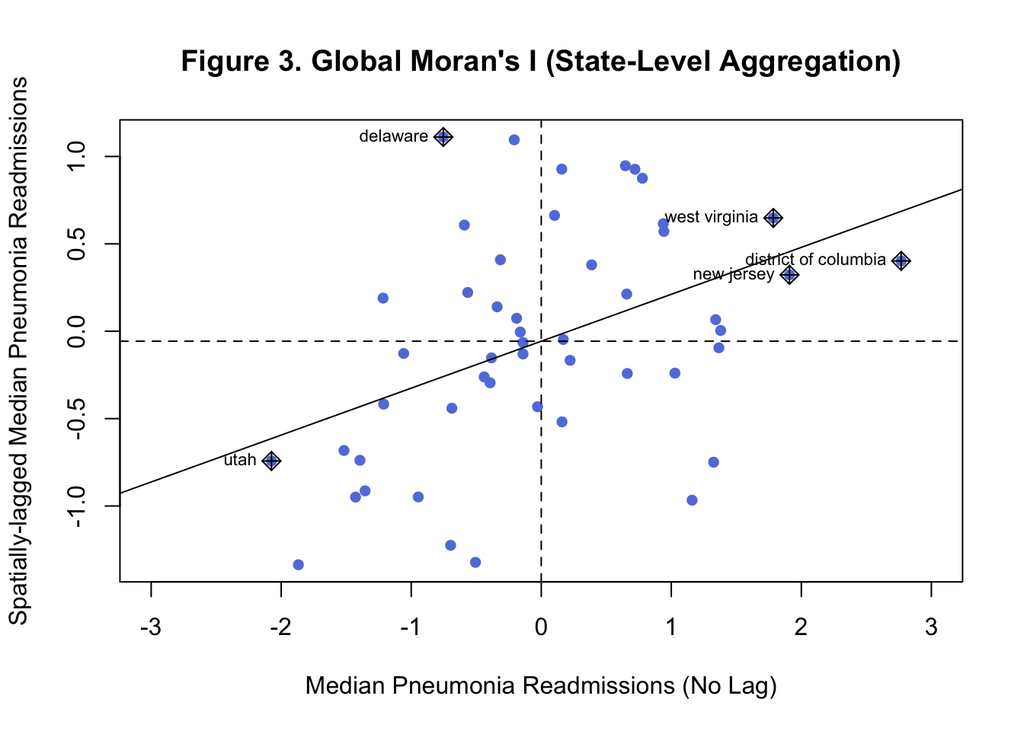

```r
## Show a plot of the top most outlier states
moran.plot(as.vector(y),
           listw = states_sw,
           ylab = "Spatially-lagged Median Pneumonia Readmissions",
           xlab = "Median Pneumonia Readmissions (No Lag)", pch = 16,
           col = skittles[2], xlim = c(-3,3),
           main = "Figure 3. Global Moran's I (State-Level Aggregation)")
```

**Interpretation**: Our global spatial autocorrelation test found a Moran’s $I$ of 0.268 with a $p$-value of 0.0014, which is less than 0.05. Thus, we reject the $H_0$ of a random distribution and conclude that we have **significant positive spatial autocorrelation** for median pneumonia-related readmissions! This suggests that states with similar median readmission rates *tend to be clustered geographically* in the U.S.!

- **High-high outliers** (Quadrant I)
  - These states have especially high readmission rates and are generally surrounded by neighboring states that are also high.
- **Low-high outliers** (Quadrant II)
  - These states have low readmission rates but are generally surrounded by neighboring states that are high.
- **Low-low outliers** (Quadrant III)
  - These states have especially low readmission rates and are generally surrounded by neighboring states that are also low.
- **High-low outliers** (Quadrant IV)
  - These states have high readmission rates but are generally surrounded by neighboring states that are low.

#### **Question 13**: [1 point]

Identify each of the outliers from the graph and interpret the type of outlier (high-high, low-high, etc.) that they are.

**Answer:**

The plot labels five outlier states:

1. District of Columbia — High-High (Quadrant I): very high readmissions with high-readmission neighbors; the most extreme outlier on the value axis.
2. West Virginia — High-High (Quadrant I): high readmissions surrounded by high neighbors.
3. New Jersey — High-High (Quadrant I): high readmissions surrounded by high neighbors.
4. Delaware — Low-High (Quadrant II): below-average readmissions itself, but surrounded by high-readmission neighbors.
5. Utah — Low-Low (Quadrant III): very low readmissions surrounded by low-readmission neighbors.

Four of the five (DC, WV, NJ, Utah) reinforce the positive spatial autocorrelation — they’re “with their own kind” (high with high, low with low). Delaware is the one spatial misfit (low value among high neighbors), which is why it stands out as an outlier in the opposite direction.

#### **Question 14A**: [0.5 points]

**NOTICE** that I had you define the target as a *centered* version of `Median_RawPredictedReadmissionRate`, which is the median of the *untransformed, unscaled* readmissions. Shouldn’t I have used the transformed and scaled version, `bc_PredictedReadmissionRate`? Can you think of any reason why I chose to use the centered median of the raw readmissions rather than the transformed version?

**Answer:** Centering is the step that matters, not scaling. while scaling adjusts the range of the data (both are used to standardize the data)

**HINT 1**: What does centering do that scaling does not? Could centering be important, for example, to make sure that $y$ is going in the same direction as lagged $y$?

**HINT 2**: Why do we need $y$ and lagged $y$ going in the same general directions? Could it have anything to do with identifying which **quadrant** they fall into?

**HINT 3**: [Chapter 8](https://www.paulamoraga.com/book-spatial/spatial-autocorrelation.html) by Paul Moraga on Spatial Autocorrelation may be helpful, but it also gets a bit deep in the weeds too.

#### **Question 14B**: [0.5 points]

Now go back up to temporarily **reset the target** to `bc_PredictedReadmissionRate` here. **There is no need to scale it again!** Then, re-run the Global Moran’s $I$. make sure to update the limits of the $x$-axis or just comment that line out (`xlim(...)`) to look at the graph. Looking at the value of $I$, the $p$-value, and the graph output - does the conclusion change? Does it matter which value we choose for the analysis?

```r
# reset the target** to `bc_PredictedReadmissionRate`, re-run Global Moran's

global_moran_y1 <- moran.test(states_sf_AggTrain$bc_PredictedReadmissionRate, states_sw)

## View the results
global_moran_y1
```

```
##
##  Moran I test under randomisation
##
## data:  states_sf_AggTrain$bc_PredictedReadmissionRate
## weights: states_sw
##
## Moran I statistic standard deviate = 3.1939, p-value = 0.0007019
## alternative hypothesis: greater
## sample estimates:
## Moran I statistic       Expectation          Variance
##       0.288790751      -0.020833333       0.009397939
```

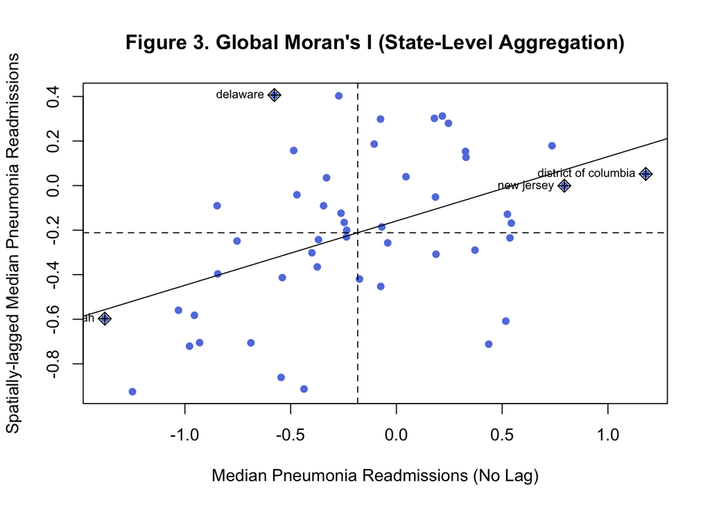

```r
## Show a plot of the top most outlier states
moran.plot(as.vector(states_sf_AggTrain$bc_PredictedReadmissionRate),
           listw = states_sw,
           ylab = "Spatially-lagged Median Pneumonia Readmissions",
           xlab = "Median Pneumonia Readmissions (No Lag)", pch = 16,
           col = skittles[2], #xlim = c(-3,3),
           main = "Figure 3. Global Moran's I (State-Level Aggregation)")
```

```r
## Change back
y <- scale(states_sf_AggTrain$Median_RawPredictedReadmissionRate,
           center = TRUE, scale = FALSE)
```

**NOTE**: Make sure to change $y$ back to the scaled version of `Median_RawPredictedReadmissionRate` before moving to the next analysis!

## 2.3 Local Spatial Autocorrelation (LISA): Local Moran’s $I$

Now that we’ve gotten a sense for possible outlier states and we know that we have global spatial autocorrelation in median readmission rates, it would be nice to concretely identify hotspots and coldspots. Unlike the global Moran’s $I$, which provides an overall measure of spatial autocorrelation across the entire nation, LISA (**L**ocal **I**ndicators of **S**patial **A**ssociation) helps pinpoint specific states that significantly contribute to that global pattern. LISA identifies clusters of similar values, such as high-high (hotspots) and low-low (coldspots). It can also be used to identify spatial high-low and low-high outliers, just as the global test did. This local approach is so powerful though because it **enables us to map and interpret where spatial clustering or dispersion is happening**, which is especially valuable for targeted policy intervention or resource allocation. So, even though it may not be as vital for our predictions, it can help us to better understand the spatial pattern of pneumonia-related hospital readmissions more generally.

## 2.3.1 Run local Moran’s I for LISA

To perform the LISA, we will use the `localmoran()` function from `spdep`. More information on the function can be found [here](https://r-spatial.github.io/spdep/reference/localmoran.html). After, instead of printing the `summary()` I show you the `head()` of the first rows produced by the LISA.

```r
## Run local Moran's I for LISA on vectorized y & applying same spatial weights
local_moran <- localmoran(as.vector(y), states_sw)
```

Table 5. First 6 rows of Local Indicators of Spatial Awareness (LISA) output

|  | Ii | E.Ii | Var.Ii | Z.Ii | Pr(z != E(Ii)) |
| --- | --- | --- | --- | --- | --- |
| alabama | -0.04 | 0.00 | 0.03 | -0.26 | 0.79 |
| arizona | 0.11 | 0.00 | 0.03 | 0.68 | 0.50 |
| arkansas | 0.00 | 0.00 | 0.00 | 0.02 | 0.98 |
| california | -0.12 | -0.04 | 0.54 | -0.11 | 0.91 |
| colorado | 0.79 | -0.01 | 0.06 | 3.36 | 0.00 |
| connecticut | 0.06 | 0.00 | 0.00 | 1.12 | 0.26 |

- `Ii` = Stands for $I_i$, which is the local Moran’s $I$ estimate for that state. $I_i$ is a measure of local spatial autocorrelation for the given state. If positive, it is similar to its neighbors, if negative it is dissimilar.
- `E.Ii` = Stands for $\mathbb{E}(I_i)$, which is the expected value of $I_i$ under the null hypothesis of spatial randomness. This value is usually close to 0.
- `Var.Ii` = Stands for $Var(I_i)$, which is the variance of $I_i$ under the null hypothesis. It is used to assess the significance of $I_i$.
- `Z.Ii` = Stands for $Z_{I_i}$, which is the $Z$-score calculated as $Z = \frac{I_i − \mathbb{E}(I_i)}{\sqrt{Var(I_i)}}$, which indicates how extreme $I_i$ is compared to the random expectation. Used to derive statistical significance.
- `Pr(z!=E(Ii))` = Stands for $Probability(Z_{I_i} \ne \mathbb{E}(I_i))$, which is the probability that $I_i$ is not equal to the expected value $\mathbb{E}(I_i)$. In other words, it’s the p-value associated with $Z_{I_i}$! So, it tells you whether the local spatial autocorrelation is statistically significant for any given state.

That might feel like a lot of confusing math, but let’s start to put it together into something meaningful we can use: **HOTSPOTS** vs. **COLDSPOTS**.

### 2.3.2 Criteria for hotspots vs. coldspots

- **Hotspots** (High-High). States with a high median readmission value surrounded by other high value states. As you get to the fringes of hotspots, other states that have high readmission rates but are surrounded by low states will not be labeled as part of the hotspot but could be labeled an outlier (high-low).
- **Coldspots** (Low-Low). States with a low median readmission value surrounded by other low value states. As you get to the fringes of coldspots, other states that have low readmission rates but are surrounded by high states will not be labeled as part of the coldspot but could be labeled an outlier (low-high).

We can actually break this down a bit to help us better understand the difference between hot/coldspots and *outliers* - outliers are states with high readmission values that are near states really different from them in terms of readmission rates.

##### Table 6. Description of the quadrants and their corresponding LISA cluster categories.

| **Readmissions** | **Neighbors** | **LISA Category** | **Quadrant** | **Explanation** |
| --- | --- | --- | --- | --- |
| High | High | Hotspot (H-H) | I | State with high readmissions is surrounded by other high states |
| Low | Low | Coldspot (L-L) | III | State with low readmissions is surrounded by other low states |
| High | Low | Outlier (H-L) | IV | State with high readmissions is surrounded by low rate states |
| Low | High | Outlier (L-H) | II | State with low readmissions is surrounded by high rate states |
| High or Low | Random | Not Sign. (N.S.) | - | No difference from random (dispersed) |

This implies, then, that if we **identify the quadrants** we identify the hot/coldspots! So, let’s do that.

#### **Question 15A**: [1 point] TT

- Hotspots (Quadrant I, “High-High”) will be states that have:
- A significant $p$-value ($p < 0.05$), which suggests that local $I_i$ is significantly **positive** ($I_i > 0$)
- A *centered* median hospital pneumonia-related readmissions rate that is positive
- A **spatially-lagged** median hospital pneumonia-related readmissions rate that is positive

**What will the criteria for coldspot (quadrant III) states be?**

**Answer:**

Coldspots (Quadrant III, “Low-Low”) will be states that have:

1. A significant pp p-value (p<0.05), which suggests that local $I_i$ is significantly positive
2. A centered median hospital pneumonia-related readmissions rate that is negative
3. A spatially-lagged median hospital pneumonia-related readmissions rate that is negative

#### 2.3.2.1 Extract the spatially-lagged median hospital readmission rates

```r
lag_medianReadmissions <- lag.listw(states_sw, y)
## Run this is you want to see what they look like!
lag_medianReadmissions
```

```
##               [,1]
##  [1,]  0.139521939
##  [2,] -0.294953061
##  [3,] -0.004411395
##  [4,] -0.094786395
##  [5,] -1.224960204
##  [6,]  0.662580272
##  [7,]  1.111313605
##  [8,]  0.402271939
##  [9,] -0.239853061
## [10,] -0.064403061
## [11,] -0.949028061
## [12,]  0.004046939
## [13,]  1.094934439
## [14,] -0.127353061
```

[output cut: 35 more lines]

```r
## Just Massachusetts' value:
#lag_medianReadmissions[20]
```

#### **Question 15B**: [0.5 points] TT

The raw target is the % of all pnuemonia patients discharged who are predicted to be readmitted within 30 days after being released from the hospital. So, e.g., the *raw* median pneumonia-related readmissions rate for Massachusetts is 16.6789, meaning that $\approx$ 16.7% (no multiplication by 100 needed here!) are predicted to be readmitted based on a sliding-window average of 30-day readmissions.

Yet, the *spatially-lagged* pneumonia-readmissions for Massachusetts is only 0.2126469!

**QUESTION**: Why do the spatially-lagged variables seem SO shifted compared to the original value?

**HINT**: What did we do to the raw hospital readmissions before we calculated the spatial weights in this section?

**Answer:** The spatially-lagged values look so shifted because the target y was centered, also influenced y neighbor states value.

#### **Question 15C**: [0.5 points] TT

Show just Massachusetts’ median readmissions to see its value after performing the step I am referring to in the hint.

**HINT**: Massachusetts is at row 20 in the `states_sf_AggTrain` dataframe, which will make it easier to locate its value in the vector created by looking at just the `Median_RawPredictedReadmissionRate` column.

```r
## Your code here.
scaled_readmissions <- scale(states_sf_AggTrain$Median_RawPredictedReadmissionRate)

#Massachusetts' value (row 20)
scaled_readmissions[20]
```

```
## [1] 0.6261563
```

```r
#The spatially-lagged value
lag_medianReadmissions[20]
```

```
## [1] 0.2126469
```

**QUESTION**: Is this a lot closer to the spatially-lagged value?

#### 2.3.2.2 Convert the LISA results to a dataframe

```r
local_df <- local_moran %>% as_data_frame()
```

#### 2.3.2.3 Add the local $I_i$, $p$-value, and lagged readmissions to the `states_sf_AggTrain` dataset

```r
states_sf_AggTrain <- states_sf_AggTrain %>%
  mutate(
    ## adds the local I
    localI = local_df$Ii,
    ## adds the p-value
    pValue = local_df$`Pr(z != E(Ii))`,
    ## adds the lagged median readmissions
    lag_medianReadmissions = lag_medianReadmissions
  )
```

#### 2.3.2.4 Classify the LISA quadrants (hot/coldspots) based on the criteria

The criteria we used (in case you already forgot!) were set here. All of the steps might make it easy to forget what we are trying to do, but we’re finally at the important part: **identifying the quadrants**.

#### **Question 15D**: [0.5 points]

The code below identifies the quadrants and adds them to the `states_sf_AggTrain` dataset. Your task is to add comments to the code below where indicated. Make sure to refer back to the criteria we set here if needed!

> Answer in the comments.

```r
## this code is creating a new variable to classify each state into a quadrant
## spatial outlier, or not-significant, based on the LISA criteria (value sign, lag sign, p-value).
states_sf_AggTrain <- states_sf_AggTrain %>%
  mutate(
    ## Use case_when() to assign each state to a quadrant; it checks conditions
    ## put this state in this quadrant when....
    quadrant = case_when(
      ## if the p-value is not significant (signified by a 'N.S.')
      ## ## (not significant) — this gate runs first so all remaining lines only see
      ## significant states.
      pValue >= 0.05 ~ "N.S.",
      ## case_when() evaluates top-to-bottom and stops at the
      ## first match. The line above already sent every non-significant state (p >= 0.05)
      ## to "N.S.", so any state reaching this point has already passed p < 0.05 —
      ## no need to re-check significance.
      #We don't care about it, as the state is already deemed significangt so the actual value is not important.

      ## Quadrant I (High-High): the state's own centered rate is positive (above the
      ## mean) AND its neighbors' lagged rate is positive (also above the mean) = Hotspot.
      #If both the state’s readmission rate (y) and its neighbors’ (lag) are above the mean =High-High cluster ="Hotspot"
      #Quadrant I
      y > 0 & lag_medianReadmissions > 0 ~ "Hotspot",

      ## Quadrant III (Low-Low): the state's own centered rate is negative (below the
      ## mean) AND its neighbors' lagged rate is negative (also below the mean) = Coldspot.
      #If both the state’s readmission rate and neighbors’ are below the mean =Low-Low cluster ="Coldspot"
      #Quadrant III
      y < 0 & lag_medianReadmissions < 0 ~ "Coldspot",


      #If both the state has a high readmission rate, but its neighbors are low =High-Low mismatch ="High-Low Outlier"
      #Quadrant IV
      y > 0 & lag_medianReadmissions < 0 ~ "High-Low Outlier",

      ### Quadrant IV (High-Low): the state's own rate is high (y > 0) but its neighbors
      ## are low (lag < 0) — a spatial mismatch = High-Low Outlier.
      #If both the state has a low readmission rate, but its neighbors are high =Low-High mismatch ="Low-High Outlier"
      #Quadrant II
      y < 0 & lag_medianReadmissions > 0 ~ "Low-High Outlier",

      ## Fail-safe: if a state somehow matches none of the above, assign NA.
      #A fail-safe in case a state misses all of the above criteria.
      TRUE ~ NA
    )
  )
```

#### 2.3.2.5 Map the LISA cluster (quadrants)

Lastly, let’s visualize our hot/cold spots on the map! Note that we are now using `geom_sf()` for mapping rather than `geom_polygon()`. This is because our dataframe now contains **shapefile** geometries instead of just the polygons that it did earlier, hence the change.

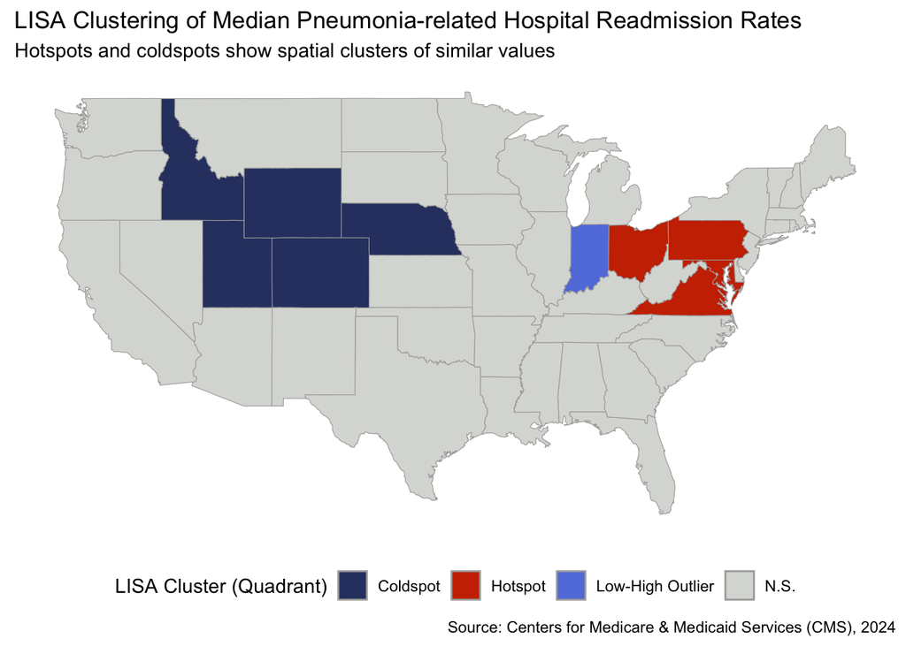

#### **Question 15E**: [0.5 points] TT

Interpret what it means if Indiana is a “low-high” outlier.

**Answer:** Being a “low-high” outlier means that Indiana has a lower-than-average pneumonia readmission rate, but it is surrounded by neighboring states that have higher-than-average readmission rates. On the map, Indiana sits right next to the Mid-Atlantic hotspot cluster (Ohio, etc.), so its low value stands out against high-readmission neighbors. Unlike a hotspot or coldspot, its local Moran’s I is negative (dissimilar from neighbors), which is what distinguishes outliers from clusters.

#### **Question 15F**: [1 point] TT

Do the hot and coldspots make sense with your observations of graph `p1`? Why or why not? Can you explain why hot/coldspots will not necessarily correspond with **individual states’** high and low median readmission rates?

Because a LISA cluster is defined by a state’s value together with the weighted average of its neighbors, and by statistical significance, not by the state’s own rate alone. Indiana is the perfect example: a low individual rate that becomes an outlier because of its high-value neighbors.

They somewhat mimic the lighter shaded states from the ‘p1’ graph Hot/cold hotpots will not necessarily correspond with the rates becuse they are based on spatial relationships between clusters.

## 2.4 Spatial Regression Models

**Spatial regression models** explicitly account for spatial relationships in data, which is something we encounter constantly in public health and epidemiology, as well as environmental studies (e.g., climate change, pollution, wildfire risk), agriculture (e.g., soil nutrients, water availability), sociology and social work (e.g., poverty, social justice), criminology (e.g., real-time crime predictions), and business (e.g., real-estate and housing prices). In other words, spatial regression gives us tools to analyze *how nearby locations influence each other*, especially when spatial relationships **violate the assumption of independence in OLS regression!**

There are two common issues that spatial regression addresses:

1. **Spatial dependence**, in which outcomes in nearby locations tend to be similar (e.g., rates of a transmissable disease tend to be higher in nearby areas vs. farther areas).
2. **Spatial heterogeneity**, in which relationships between variables may vary across space (e.g., housing prices, climate, or wildfire risk depend on geographic features of the landscape, sometimes features we have not even measured).

### 2.4.1 Spatial Lag/Autoregressive Regression (SAR)

There are three types of spatial regression models worth mentioning. The **spatial lag model (aka, Spatial Autoregressive Model or SAR)** is the one we will focus on first. In this regression model, the outcome depends on neighboring outcomes. This makes sense for us because we know from the LISA analysis that we have hot/coldspots of pneumonia-related readmissions!

The general structure of the SAR model is:

$y = \rho Wy + \beta_1 X_1 + \beta_2 X_2 + ... \beta_n X_n +\epsilon$

where $y$ is the target variable (median pneumonia-related readmissions), $W$ is the spatial weights matrix, which defines the neighborhoods (stored in `states_sw`!), and $\rho$ is the _spatial lag coefficient__. This means that the first term of the equation, $\rho Wy$, measures the spatial lag of the target variable as the average of neighbors’ outcomes multiplied by the spatial lag coefficient. It tells us **how much the outcome deviates just do to spatial relationships with neighbors!**. The remaining terms, $\beta_1 X_1 + \beta_2 X_2 + ... \beta_n X_n$ are just the standard regression coefficients for each of the $n$ predictors. $\epsilon$ is an unmeasured error term, which we also have in OLS regression.

We are justified in proceeding with a SAR because, as you hopefully remember from the end of Project 1, pneumonia-related hospital readmissions could be predicted with an OLS regression! However, we also know we have spatial patterns here that we want to try account for in our predictive models, so let’s do that now.

#### **Question 16**: [1 point] TT

Your data have already been partitioned into training and testing sets, preprocessed and normalized, and we just calculated the spatial weights matrix, $W$. What if we did NOT already have the data fully pre-processed? In a few sentences, describe the steps we would have to take if we were starting from the raw data.

**HINT**: Think of the data science lifecycle/flow we keep coming back to!

**Answer:** If we did not have pre-processed data, we would first clean and process the data. split into training and testing sets first, so that all subsequent pre-processing (transforming skewed variables, centering/scaling, dropping collinear features) is fit on the training set only to avoid data leakage. We’d then aggregate to the state level, calculate the spatial weights matrix WW W, and finally fit the model.

### 2.4.1.1 For our convenience, make a dataframe that contains just the information we want for fitting the SAR and store it into `sarTrain`

```r
            ## Start from the training data
sarTrain <- states_sf_AggTrain %>%
  ## Make it a dataframe/tibble
  as_data_frame() %>%
  ## Drop the features that we dropped before the analysis in Project 1, as
  ## well as the features we do NOT want to use as predictors!
  select(-Median_RawPredictedReadmissionRate,
         -Median_RawMedicareSpending,
         -Median_RawHospitalReturnDays,
         -Median_RawDeathRate,
         -ID,
         -localI,
         -pValue,
         -quadrant,
         -geom,
         -lag_medianReadmissions)
```

### 2.4.1.2 For comparison, let’s fit the OLS regression of the Box-Cox transformed pneumonia-related readmissions against the predictors

```r
OLS <- lm(bc_PredictedReadmissionRate ~ ., data = sarTrain)
```

#### **Question 17A**: [0.5 points] TT

Why am I fitting an OLS regression again?

**HINT 1**: There are actually TWO reasons! But you only need one for full credit…

**HINT 2**: What did aggregation do to our sample size?

**Answer:** When we aggregated the data, our sample size decreased. Refitting the model would allow for a more accurate reflection of the smaple size and the relationships between the variables.The Project 1 OLS was fit on hospital-level data, so we refit on the aggregated state-level data to get a model and coefficients that actually correspond to the units we’re now analyzing spatially.

### 2.4.1.3 Check residuals for spatial autocorrelation

If we didn’t already know that we have spatial relationships from the Moran’s $I$ and the LISA, we could also consider calculating a Moran’s $I$ on the residuals of the OLS regression. This would tell us, even if we had NOT yet done a Moran’s $I$ or LISA, that whether we should pay more attention to our spatial relationships and explicitly include them in our regression model.

$H_0$: The null hypothesis is that the residuals are not spatially autocorrelated. Thus, the OLS is not misspecified and we do not need to worry about spatial relationships in our target.

```r
## Moran's I test on residuals
moran.test(residuals(OLS), states_sw)
```

```
##
##  Moran I test under randomisation
##
## data:  residuals(OLS)
## weights: states_sw
##
## Moran I statistic standard deviate = 1.5437, p-value = 0.06133
## alternative hypothesis: greater
## sample estimates:
## Moran I statistic       Expectation          Variance
##       0.128852929      -0.020833333       0.009402604
```

#### **Question 17B**: [1.5 points] TT

- What would we conclude from the results of the Moran’s $I$ test on the **residuals**?

**Answer:** Because the p-value is greater than 0.05, we would conclude that there is no spatial autocorrelation.

- If we had started here, rather than calculating the Moran’s $I$ and LISA first, could we have been potentially mistaken about spatial relationships? Why or why not?

**Answer:** Yes, we could have missed a lot of information regarding the spatial relationships. While the OLS can explain variation in our target variables (readmission), missing these steps could result in incorrect analysis and undermining the importance of certain spatial relationships.

- Why might these results disagree with what we found from the Moran’s $I$ and LISA on the scaled target?

**Answer:** These results might disagree because they are looking are related, yet separate portins of the data. While the Moran’s I and the LISA test for spatial autocorrelation, the Moran’s I on the residuals teset for any spatial patterns that are left after looking at the predictors.

### 2.4.1.4 Fit the SAR model

The `lagsarlm()` from the `spatialreg` package will fit the SAR for us, allowing us to specify the spatial weights matrix, `states_sw`, that we calculated all the way back here.

```r
## SAR (spatial lag model)
SAR <- lagsarlm(bc_PredictedReadmissionRate ~ ., data = sarTrain,
                      listw = states_sw)

summary(SAR)
```

```
##
## Call:lagsarlm(formula = bc_PredictedReadmissionRate ~ ., data = sarTrain,
##     listw = states_sw)
##
## Residuals:
##       Min        1Q    Median        3Q       Max
## -0.657380 -0.240268 -0.011297  0.205659  0.748405
##
## Type: lag
## Coefficients: (asymptotic standard errors)
##                                                                 Estimate
## (Intercept)                                                    0.0037668
## MRSA.Bacteremia                                               -0.1085416
## Abdomen.CT.Use.of.Contrast.Material                           -0.0323645
## Death.rate.for.pneumonia.patients                             -0.0659404
## Postoperative.respiratory.failure.rate                        -0.5704259
## Perioperative.pulmonary.embolism.or.deep.vein.thrombosis.rate  0.9855298
## Composite.patient.safety                                      -0.3809309
## Medicare.spending.per.patient                                  0.4864549
## Healthcare.workers.given.influenza.vaccination                 0.0336501
## Left.before.being.seen                                         0.0319323
## Venous.Thromboembolism.Prophylaxis                            -0.1223090
## Doctor.communication                                           0.3979458
## Communication.about.medicines                                 -0.2554363
## Discharge.information                                         -0.2890223
## Cleanliness                                                   -0.2588597
## Quietness                                                     -0.3024060
## Hospital.return.days.for.pneumonia.patients                    0.0927036
##                                                               Std. Error
## (Intercept)                                                    0.0803023
## MRSA.Bacteremia                                                0.2512056
## Abdomen.CT.Use.of.Contrast.Material                            0.1629524
## Death.rate.for.pneumonia.patients                              0.2029840
## Postoperative.respiratory.failure.rate                         0.3537272
## Perioperative.pulmonary.embolism.or.deep.vein.thrombosis.rate  0.2706225
## Composite.patient.safety                                       0.2174500
## Medicare.spending.per.patient                                  0.1476588
## Healthcare.workers.given.influenza.vaccination                 0.1160326
## Left.before.being.seen                                         0.1466825
## Venous.Thromboembolism.Prophylaxis                             0.2325981
```

[output cut: 22 more lines]

```
## Quietness                                                     -2.3428 0.0191393
## Hospital.return.days.for.pneumonia.patients                    0.6972 0.4856566
##
## Rho: 0.33291, LR test value: 4.7905, p-value: 0.028617
## Asymptotic standard error: 0.13262
##     z-value: 2.5102, p-value: 0.012065
## Wald statistic: 6.3013, p-value: 0.012065
##
## Log likelihood: -12.75033 for lag model
## ML residual variance (sigma squared): 0.095777, (sigma: 0.30948)
## Number of observations: 49
## Number of parameters estimated: 19
## AIC: 63.501, (AIC for lm: 66.291)
## LM test for residual autocorrelation
## test value: 0.05318, p-value: 0.81762
```

### 2.4.1.5 Interpret the SAR model

The `summary()` output of the SAR model shows a lot going on. Let’s go through the three key pieces of evidence we want to assess from these results.

1. Spatial Autoregressive Coefficient ($\rho$, “Rho”)

Here, we find that $\rho = 0.33291$ with an estimated p-value of $p = 0.012065$ based on a Z-statistic of $Z = 2.5102$. What the Wald Z-test is doing is testing whether $\rho = 0$, just like in Pearson correlation tests!

**CONCLUSION**: With a p-value LESS than 0.05, we would conclude that $p \ne 0$ - thus there is *sufficient spatial dependency in the target variable to justify including the lag term in this model*. That’s opposite what the Moran’s $I$ on the residuals implied but feels very consistent with what we found for both global and local Moran’s $I$ earlier.

2. Likelihood Ratio Test

More generally, Likelihood Ratio Tests (LRTs) are used to compare **well one nested regression model fits compared to an unnested model**. If you’ve ever done stepwise regression, you’ve inherently done a Likelihood Ratio Test possibly without knowing it! Note that because SAR is a nested model, it reduces to OLS when the spatial lag coefficient $\rho = 0$. When there is NO spatial lag ($\rho = 0$), the first term of the SAR model cancels out!

The `lagsarlm()` unfortunately will not automatically compare the Spatial Lag Model (SAR) with the Ordinary Least Squares (OLS) model - **but we can**. We will do this by separately performing a Likelihood Ratio Test (LRT). But the LRT test is very simple. The formula for the likelihood ratio (LR) of the two models can be found by:

$LR = 2 \times (\log L_{SAR} - \log L_{OLS})$

where $\log L_{SAR}$ is the log-likelihood of the SAR model and $\log L_{OLS}$ of the OLS model. The LR test statistic follows a $\chi^2$ distribution with 1 degree of freedom.

But if that feels too mathy for your, just remember this: **A LR of 0 means there is NO difference between the two models being compared, but the bigger the LR the higher the probability that the two models are different.** Thus, our $H_0$ (null hypothesis) is that there is no difference between the SAR model and the OLS. So, if our $p$-value is less than 0.05, we will reject that null hypothesis.

In the output, the $\log L_{SAR} = -12.75$ but the $\log L_{OLS}$ isn’t shown. We can very quickly perform the LRT in `R` using the `anova()` function. **NOTE** that this function is confusingly named here; it will either do an Analysis of Variance (ANOVA) or an Analysis of Deviance, also known as the Likelihood Ratio Test which is what we are doing here!

```r
## Give it the larger model first, then the null model.
## SAR is our larger model; the null OLS is nested within the SAR because
## the SAR = OLS when rho = 0!
anova(SAR, OLS)
```

```
##     Model df    AIC  logLik Test L.Ratio  p-value
## SAR     1 19 63.501 -12.750    1
## OLS     2 18 66.291 -15.146    2  4.7905 0.028616
```

This tells us that the log-likelihood of SAR ($\log L_{SAR}$) is -12.75, the log-likelihood of OLS is ($\log L_{OLS}$) is -15.146, and the likelihood ratio (LR) statistic is 4.7905 with an estimated $p$-value of 0.028616. Although it does not say this, the degrees of freedom is 1 here: 19 df from SAR - 18 df from OLS.

Thus, if we wanted to do it by “hand” (i.e., calculate it according to the formula), it would look like this:

```r
## Likelihood ratio test by "hand"

## Extract the log-likelihoods for each model
logLik_OLS <- logLik(OLS)
logLik_SAR <- logLik(SAR)

## Calculate the likelihood ratio (LR) - make sure to use as.numeric()!
LR <- 2 * (as.numeric(logLik_SAR) - as.numeric(logLik_OLS))
## Find the estimated p-value for the LR statistic using the chi-squared
## distribution. Use the df = 19-18 that we observed above.
p <- pchisq(LR, df = 1, lower.tail = FALSE)

## Print the results!
cat("The likelihood ratio LR =", LR, "with 1 degree of freedom has p =", p)
```

```
## The likelihood ratio LR = 4.790534 with 1 degree of freedom has p = 0.02861655
```

Which is the same as what the `anova()` function gave us!

**CONCLUSION**: With a $p$-value LESS than 0.05, we would conclude that there is a difference between the two models. The more complex model, SAR, adds sufficient information to the model to help its fit. Thus, there is *sufficient evidence that a spatial model improves our predictive ability over what an OLS alone would*. Again, that’s opposite what the Moran’s $I$ on the residuals implied but feels very consistent with what we found for both global and local Moran’s $I$ earlier.

3. Lagrange Multiplier (LM) Test for Residual Spatial Autocorrelation

The LM test is based on the spatially lagged residuals and compares the residual spatial pattern to what would be expected under independence - meaning that it’s similar to the test we did earlier when we tested whether there was a spatial pattern to the OLS residuals! These are very similar tests, albeit calculated in slightly different ways.

The null hypothesis ($H_0$) again is that there is NO spatial pattern to the residuals; the difference now is that **we are testing if there’s still “leftover” spatial autocorrelation in the residuals AFTER fitting our SAR model**. In other words - did the SAR model do a sufficiently good job at dealing with spatial autocorrelation? If yes, yay! We’re done! If no, we’d need to do a Spatial Error Model (SEM) or Spatial Durbin Model (SDM), the other two types of regression I alluded to wayyyy back at the beginning of this section.

Our LM test statistic, per the `summary()` output, is 0.05318 with a $p$-value of 0.81762.

**CONCLUSION**: With a $p$-value MORE than 0.05, we could conclude that there is NO residual spatial autocorrelation after fitting the SAR. Thus, the SAR model is sufficient for explaining the spatial autocorrelation in the target!

#### **Question 18**: [3 points] TT

Briefly summarize everything we know at this point: (1) Global Moran’s $I$ results, (2) Local Moran’s $I$ (LISA) results, (3) Moran’s $I$ on the residuals of the OLS model, (4) the test for spatial autoregression using the coefficient $\rho$, (5) the Likelihood Ratio Test (LRT), and (6) the LM test for residual spatial autocorrelation after fitting the SAR model. DO NOT simply copy my interpretations but instead try to make sure you understand each of these pieces of evidence and what they tell us.

> 1. Global Moran’s I results: I = 0.27 (p = 0.0014). There is significant positive spatial autocorrelation in median pneumonia readmissions.
> 2. Local Moran’s I (LISA) results: This localized the global pattern.So we now know where the clustering happens, not just that it exists.
> 3. Moran’s I on the residuals of the OLS model: I = 0.13 (p = 0.061). This tests whether spatial structure remains after the OLS predictors explain part of the target.
> 4. Test of the spatial lag coefficient (ρ):ρ = 0.33 (p = 0.012). This tests whether neighbors’ outcomes influence a state’s outcome. Since ρ is significantly different from zero, there is genuine spatial dependence and the spatial lag term belongs in the model.
> 5. Likelihood Ratio Test (SAR vs OLS): LR = 4.79 (p = 0.029). This compares model fit. Because the SAR fits significantly better than OLS, the added spatial term genuinely improves the model
> 6. LM test for residual autocorrelation after SAR: LM = 0.05 (p = 0.82). This checks whether any spatial structure is left over once the SAR is fit.

What is your **final takeaway**? Do we need to account for spatial autocorrelation in our regression model?

**Answer:** Yes — we need to account for spatial autocorrelation, and the SAR model is the right way to do it.

### 2.4.1.6 Inferential statistics - which predictors are important?

Table 7. Spatial Lag (SAR) Regression results.

| **Coefficient** | **Beta**<sup>1</sup> | **SE** | **p-value** |
| --- | --- | --- | --- |
| rho | 0.33* | 0.133 | 0.012 |
| (Intercept) | 0.00 | 0.080 | >0.9 |
| MRSA.Bacteremia | -0.11 | 0.251 | 0.7 |
| Abdomen.CT.Use.of.Contrast.Material | -0.03 | 0.163 | 0.8 |
| Death.rate.for.pneumonia.patients | -0.07 | 0.203 | 0.7 |
| Postoperative.respiratory.failure.rate | -0.57 | 0.354 | 0.11 |
| Perioperative.pulmonary.embolism.or.deep.vein.thrombosis.rate | 0.99*** | 0.271 | <0.001 |
| Composite.patient.safety | -0.38 | 0.217 | 0.080 |
| Medicare.spending.per.patient | 0.49*** | 0.148 | <0.001 |
| Healthcare.workers.given.influenza.vaccination | 0.03 | 0.116 | 0.8 |
| Left.before.being.seen | 0.03 | 0.147 | 0.8 |
| Venous.Thromboembolism.Prophylaxis | -0.12 | 0.233 | 0.6 |
| Doctor.communication | 0.40 | 0.205 | 0.052 |
| Communication.about.medicines | -0.26 | 0.243 | 0.3 |
| Discharge.information | -0.29 | 0.186 | 0.12 |
| Cleanliness | -0.26 | 0.200 | 0.2 |
| Quietness | -0.30* | 0.129 | 0.019 |
| Hospital.return.days.for.pneumonia.patients | 0.09 | 0.133 | 0.5 |

Abbreviations: CI = Confidence Interval, SE = Standard Error  
<sup>1</sup> *p<0.05; **p<0.01; ***p<0.001

#### **Question 19**: [2 points] TT

We can think of dealing with **spatial spillover** as helping us distinguish the wheat from the chaff (truth from noise). **Interpret** which of the coefficients are significant ($p$-value < 0.05) AND compare that to both Table 10 (parsimonious OLS model results) AND Figure 20 (Feature Importance from Elastic Net) from **Project 1**. Now that we are accounting for spatial autocorrelation, which predictors are still important? Did any become significant (important) now that weren’t before?

**Answer:** In the SAR model, three predictors are significant (p < 0.05): Perioperative PE/DVT rate (+0.99), Medicare spending per patient (+0.49), and Quietness (−0.30). The spatial lag ρ (0.33, p = 0.012) is also significant, confirming spatial dependence.

```r
1+1
```

```
## [1] 2
```

Recall that our goal for our stakeholder is to be able to **predict(!)** which hospitals perform better than others. They want to make a deployable tool for patients/customers. So, let’s test the predictive ability of our model by using our testing data to calculate the $RMSE$.

1. *First, join the testing data with the shapefile, then create a test dataset suitable for SAR:*

This is called “spatially embedding” our testing data. Notice that we are using the spatial weights **from the training set** to prevent data leakage!!

```r
## Join the shapefile with spatial weights and neighbor lists back to the
## testing data
states_sf_AggTest <- left_join(states_sf, stateAggTest,
                                by = c("ID" = "region"))

            ## Start from the testing data
sarTest <- states_sf_AggTest %>%
  ## Make it a dataframe/tibble
  as_data_frame() %>%
  ## Move the ID column to the rownames
  column_to_rownames("ID") %>%
  ## Drop the features that we dropped before the analysis in Project 1, as
  ## well as the features we do NOT want to use as predictors!
  select(-Median_RawPredictedReadmissionRate,
         -Median_RawMedicareSpending,
         -Median_RawHospitalReturnDays,
         -Median_RawDeathRate,
         -geom) %>%
  ## Have to drop any missing values from the testing data
  drop_na()
```

2. *Now, perform the predictions using the testing data and the SAR model we already fit:*

The `spatialreg` package has its own version of the `predict` function, which will take the SAR model, the testing data, and the spatial weights (`states_sw`).

```r
predictions <- predict(SAR, newdata = sarTest, listw = states_sw) %>% as_tibble()
## Returns as a list; so make sure to turn into a dataframe for convenience
```

Table 8. First 6 rows of SAR predictions using the testing data.

| State | fit | trend | signal |
| --- | --- | --- | --- |
| alabama | -0.29 | -0.36 | 0.07 |
| arizona | 0.31 | 0.49 | -0.19 |
| arkansas | -0.32 | -0.32 | 0.01 |
| california | 0.30 | 0.49 | -0.19 |
| colorado | -0.75 | -0.50 | -0.25 |
| connecticut | 0.85 | 0.51 | 0.34 |

We can see that the predictions contain the following components:

- `fit`: the **predicted outcome** $\hat{y}$; here, this includes the influence of the spatial lag!
- `trend`: the combination of linear predictor(s) for each value of the target $y$; here, this is a combination of all $\beta_1X_1 + ... \beta_nX_n$ in our model - so all of the predictors and their coefficients
- `signal`: the spatial term, $\rho Wy$; this is the influence that the spatial autocorrelation has on each value of the target $y$
3. *Calculate the RMSE:*

We will use the `fit` component from the predictions to calculate RMSE.

```r
## Calculate RMSE using the `fit` values
sarRMSE <- sqrt(mean((sarTest$bc_PredictedReadmissionRate - predictions$fit)^2))
```

4. *Compare that with the RMSE from the OLS:*

To be able to determine how much better a job its doing (if any), we need to compare the RMSE of the new OLS (not the one from Project 1) to the RMSE from the SAR model we just calculated.

```r
olsPredictions <- predict(OLS, newdata = sarTest)
olsRMSE <- sqrt(mean((sarTest$bc_PredictedReadmissionRate - olsPredictions)^2))
```

Table 9. Comparison of RMSE for OLS and SAR models.

| Model | RMSE |
| --- | --- |
| OLS | 1.33 |
| SAR (Spatial Lag) | 1.15 |

#### **Question 20A**: [0.5 points]

Why is it challenging to interpret this RMSE in terms of the original/raw median pneumonia-related hospital readmissions? (I know.. I know… you’ve gotten it by now. Just checking.)

**Answer:** RMSE alone isn’t sufficient to explain spatial autocorrelation, we will need other test to support too.

**So, let’s add the Mean Absolute Error (MAE) as well, which may be easier to interpret**.

```r
## OLS MAE
olsMAE <- mean(abs(sarTest$bc_PredictedReadmissionRate - olsPredictions))

## SAR MAE
sarMAE <- mean(abs(sarTest$bc_PredictedReadmissionRate - predictions$fit))
```

Table 10. Comparison of RMSE for OLS and SAR models.

| Model | RMSE | MAE |
| --- | --- | --- |
| OLS | 1.33 | 0.84 |
| SAR (Spatial Lag) | 1.15 | 0.79 |

#### **Question 20B**: [1.5 points]

Interpret the MAE **and** the RMSE. Which model is better? Don’t forget to interpret the RMSE in terms of the transformed target!

**Answer:** Above result show us, SAR model is better than the OLS regression model. Lower MAE and RMSE indicates better accuracy.

### 2.4.2 Other Types of Spatial Regression Models

The results of our SAR showed that we did not need to worry about any other types of spatial regression because the LM Test for spatial autocorrelation of the residuals was not significant. Still, I want to take a brief moment to explain what those models are and how we do them, using our current data as an example. They are important enough alternatives to the SAR we may need them in the future!

**In both of these cases**, you’d consider these if your LM Test for residual spatial autocorrelation was **significant**.

### 2.4.2.1 Spatial Error Model

We’ve discussed how the SAR only models spatial “spillover” into the target, but we’ve also peeked at whether we have spatial spillover in the residuals (errors). Why would we care? **One of the fundamental assumptions of an OLS regression is independence of our error terms**, which is something we typically do not test for because we assume we have it based on our research/experiment/analytical design. But the moment we have spatial dependence, well, we may potentially violate this key assumption!

In our case, after controlling for all known predictors and modeling spatial dependence in the target only, we were able to uphold the assumption of independence (that’s what the LM test showed). But sometimes, even after SAR, our data may still show similar residual patterns. At such a point, the next step would be to fit a Spatial Error Model (SEM).

The general structure of the SEM is:

$y = \lambda W \epsilon + \beta_1 X_1 + ... +\beta_n X_n + E$

where $y$ is the target variable (median pneumonia-related readmissions), $W$ is the spatial weights matrix, which defines the neighborhoods (stored in `states_sw`!), and $\lambda$ is the _spatial error coefficient__. This means that the first term of the equation, $\lambda W \epsilon$, measures the spatial correlation between our errors. So, if $\lambda = 0$, the spatial correlation between the errors isn’t enough to bias the standard errors. As with SAR, the remaining terms, $\beta_1 X_1 + \beta_2 X_2 + ... \beta_n X_n$ are just the standard regression coefficients for each of the $n$ predictors. $E$ is an unmeasured error term, which is now the overall error leftover after fitting the SEM regression.

Fitting the model is pretty easy using the `errorsarlm()` function:

```r
## Fit the SEM (spatial error model) using the training data and weights matrix
SEM <- errorsarlm(bc_PredictedReadmissionRate ~ ., data = sarTrain,
                        listw = states_sw)

## Uncomment to view results!
summary(SEM)
```

```
##
## Call:errorsarlm(formula = bc_PredictedReadmissionRate ~ ., data = sarTrain,
##     listw = states_sw)
##
## Residuals:
##       Min        1Q    Median        3Q       Max
## -0.627137 -0.230742 -0.030906  0.212419  0.731746
##
## Type: error
## Coefficients: (asymptotic standard errors)
##                                                                 Estimate
## (Intercept)                                                    0.0040570
## MRSA.Bacteremia                                               -0.1927576
## Abdomen.CT.Use.of.Contrast.Material                           -0.0875032
## Death.rate.for.pneumonia.patients                             -0.2111690
## Postoperative.respiratory.failure.rate                        -0.2147449
## Perioperative.pulmonary.embolism.or.deep.vein.thrombosis.rate  0.7302127
## Composite.patient.safety                                      -0.3182179
## Medicare.spending.per.patient                                  0.4806596
## Healthcare.workers.given.influenza.vaccination                -0.0044689
## Left.before.being.seen                                         0.1297515
## Venous.Thromboembolism.Prophylaxis                            -0.2324866
## Doctor.communication                                           0.4387042
## Communication.about.medicines                                 -0.0940048
## Discharge.information                                         -0.5370302
## Cleanliness                                                   -0.1512913
## Quietness                                                     -0.2218475
## Hospital.return.days.for.pneumonia.patients                    0.0842956
##                                                               Std. Error
## (Intercept)                                                    0.1240457
## MRSA.Bacteremia                                                0.2275375
## Abdomen.CT.Use.of.Contrast.Material                            0.1472948
## Death.rate.for.pneumonia.patients                              0.2039855
## Postoperative.respiratory.failure.rate                         0.3005054
## Perioperative.pulmonary.embolism.or.deep.vein.thrombosis.rate  0.2566630
## Composite.patient.safety                                       0.2052205
## Medicare.spending.per.patient                                  0.1430047
## Healthcare.workers.given.influenza.vaccination                 0.1202604
## Left.before.being.seen                                         0.1361761
## Venous.Thromboembolism.Prophylaxis                             0.2140493
```

[output cut: 20 more lines]

```
## Discharge.information                                         -2.8734 0.0040612
## Cleanliness                                                   -0.7588 0.4479551
## Quietness                                                     -1.3701 0.1706445
## Hospital.return.days.for.pneumonia.patients                    0.5966 0.5507929
##
## Lambda: 0.61363, LR test value: 5.9309, p-value: 0.014877
## Asymptotic standard error: 0.12394
##     z-value: 4.9512, p-value: 0.00000073765
## Wald statistic: 24.514, p-value: 0.00000073765
##
## Log likelihood: -12.18013 for error model
## ML residual variance (sigma squared): 0.086126, (sigma: 0.29347)
## Number of observations: 49
## Number of parameters estimated: 19
## AIC: 62.36, (AIC for lm: 66.291)
```

#### **Question 21A**: [1 point]

**Answer:** The Lambda value is positve (0.61363) which is greater than 0, and therefore indicates the residuals exhibit spatial clustering.

**WHY** might you find a significant SEM but the LM test from the SAR is NOT significant? What does that suggest about our SAR model? (This is not a trick question, we’ve already discussed it.)

**Answer:** SAR and SEM capture spatial structure in different places. The non-significant SAR LM test tells us the SAR successfully handled that structure, so we don’t need the SEM — both are detecting the same spatial signal, just framing it differently.

### 2.4.2.2 Spatial Durbin Model

The Spatial Durbin Model (SDM) extends the Spatial Lag Model (SAR) by incorporating spatial lags of both the target variable AND the predictors. The idea here is that not there may be spatial autocorrelation in not only the target but also some (if not all) of the predictors. For example, if there was a policy or some underlying demography that affected the pneumonia-related hospital readmissions of one state that ALSO influenced that of a neighboring state, and we had measured that as a predictor (e.g., poverty rates or the number of elderly in the population), then an SDM would be a good idea provided that you had a significant LM test.

The general structure of the SDM is:

$y = \rho Wy + \{\beta_1 X_1 + ... +\beta_n X_n\} + \{W_1X_1\theta_1 + ... + W_nX_n\theta_n\} + \epsilon$

where $y$ is the target variable (median pneumonia-related readmissions), $W$ is the spatial weights matrix, which defines the neighborhoods (stored in `states_sw`!), and $\rho$ is the spatial lag coefficient, making the first term of the equation, $\rho Wy$, the same as it was in SAR! The next term, $\beta_1 X_1 + \beta_2 X_2 + ... \beta_n X_n$ are just the standard regression coefficients for each of the $n$ predictors. Then comes the third term, $\{W_1X_1\theta_1 + ... + W_nX_n\theta_n\}$, which represents EACH of the spatially-lagged predictors we are including. Note that we would not have to spatially lag all predictors. As before, $\epsilon$ is an unmeasured error term.

So, just by looking at all that mathy-math, we can see this model is a lot more complicated! The advantage, however, is that it would allow us to account for spatial autocorrelation in the target and predictors simultaneously, which is immensely powerful. And I like power! (Statistical power, that is.)

Fitting the model is pretty easy using the `lagsarlm()` function:

```r
SDM <- lagsarlm(formula = bc_PredictedReadmissionRate ~ ., data = sarTrain,
  listw = states_sw, type = "mixed") ## "mixed" is necessary to specify as SDM

## Uncomment to view results!
summary(SDM)
```

```
##
## Call:lagsarlm(formula = bc_PredictedReadmissionRate ~ ., data = sarTrain,
##     listw = states_sw, type = "mixed")
##
## Residuals:
##        Min         1Q     Median         3Q        Max
## -0.5119296 -0.0856881  0.0028116  0.1329395  0.4811692
##
## Type: mixed
## Coefficients: (asymptotic standard errors)
##                                                                    Estimate
## (Intercept)                                                       -0.753483
## MRSA.Bacteremia                                                    0.181542
## Abdomen.CT.Use.of.Contrast.Material                                0.044127
## Death.rate.for.pneumonia.patients                                  0.135721
## Postoperative.respiratory.failure.rate                            -1.430492
## Perioperative.pulmonary.embolism.or.deep.vein.thrombosis.rate      1.596331
## Composite.patient.safety                                          -0.395633
## Medicare.spending.per.patient                                      0.841922
## Healthcare.workers.given.influenza.vaccination                     0.104029
## Left.before.being.seen                                            -0.025737
## Venous.Thromboembolism.Prophylaxis                                 0.399788
## Doctor.communication                                               0.335880
## Communication.about.medicines                                      0.391737
## Discharge.information                                             -0.598922
## Cleanliness                                                       -0.501820
## Quietness                                                         -0.353278
## Hospital.return.days.for.pneumonia.patients                        0.159403
## lag.MRSA.Bacteremia                                                1.556060
## lag.Abdomen.CT.Use.of.Contrast.Material                            0.234453
## lag.Death.rate.for.pneumonia.patients                              0.818625
## lag.Postoperative.respiratory.failure.rate                        -3.074017
## lag.Perioperative.pulmonary.embolism.or.deep.vein.thrombosis.rate  2.572557
## lag.Composite.patient.safety                                       0.379481
## lag.Medicare.spending.per.patient                                  0.900775
## lag.Healthcare.workers.given.influenza.vaccination                 0.146529
## lag.Left.before.being.seen                                        -0.648498
## lag.Venous.Thromboembolism.Prophylaxis                             1.813592
## lag.Doctor.communication                                          -1.028270
## lag.Communication.about.medicines                                  0.476890
```

[output cut: 104 more lines]

```
## lag.Quietness                                                             0.0013651
## lag.Hospital.return.days.for.pneumonia.patients                           0.2140089
##
## Rho: -0.3198, LR test value: 1.8085, p-value: 0.17868
## Asymptotic standard error: 0.18114
##     z-value: -1.7655, p-value: 0.077472
## Wald statistic: 3.1171, p-value: 0.077472
##
## Log likelihood: 14.78912 for mixed model
## ML residual variance (sigma squared): 0.031295, (sigma: 0.1769)
## Number of observations: 49
## Number of parameters estimated: 35
## AIC: 40.422, (AIC for lm: 40.23)
## LM test for residual autocorrelation
## test value: 6.2317, p-value: 0.012548
```

**Now, you might notice something a bit odd here**. Now, the test of the $H_0: \rho = 0$ is NOT significant (p = 0.17868) but the LM test IS significant (p = 0.012548), which is a **complete reversal**. What gives?!

The reality is that we likely have **yet unaccounted for spatial structure in the data**, in the form of OMITTED VARIABLES. Yikes! How can we deal with that if we have no idea what we omitted?!

#### TAKEAWAYS

- The SAR did a “good enough” job at inference. We’ve muddied the waters a bit by doing the SDM. Sometimes “good enough” is totally okay! However, don’t forget that for **prediction** purposes, the SAR model is not going to work.
- There are very likely to be **omitted** spatial variables. We haven’t, for example, included anything about underlying demographics or **Social Determinants of Health**.
- If we were determined to improve this, we would either
  - 1. Try a Spatial Durbin Error Model (SDEM) or
  - 2. Try to find the ommitted variables. **We are going to go with option 2!**

#### **Question 21B**: [1 point]

**Answer:** Below is workflow I think it should be Moran’s I/LISA detect → SAR for spatial lag in the target → SEM for spatial structure in the errors → SDM for spatial lag in both — escalating only as residual diagnostics demand.

##### Table 11. Comparison of spatial regression models and when to use them.

| **Model** | **Spatial Dependence In** | **Use When** |
| --- | --- | --- |
| **SAR** (Spatial Lag/Autoregressive) | Target variable | Outcome in one area is influenced by neighboring outcomes |
| **SEM** (Spatial Error) | Residuals $\epsilon$ | Unmeasured spatial effects or spatial error correlation |
| **SDM** (Spatial Durbin) | Both target and predictors | Capture spatial spillover of both outcomes and predictors |

#### **Question 22**: [2 points]

**DATA SCIENCE EXTENSIONS OF SPATIAL MODELING** $\rightarrow$ At this point, it should feel clear that we have spatial influence in our data with state-level differences in pneumonia-related hospital readmissions. Yet, building a robust predictive model is still not within our grasp. How could we get there?

Our next steps will involve moving in the direction of **adding omitted spatially correlated features**, but your first task is a thought experiment and a little research.

Do data scientists ever extract the spatially lagged targets/predictors and put them into machine learning models, like Elastic Net - or others like Random Forest or Neural Networks? Make sure to give an example from a scholarly or journalistic article.

**HINT 1**: Searching [Google Scholar](https://scholar.google.com) can be a starting point for academic articles.

**HINT 2**: The [Harvard Data Science Review](https://hdsr.mitpress.mit.edu) can be a solid starting point for articles that are more hybrid academic/journalistic.

**HINT 3**: [Medium](https://medium.com) or LinkedIn can sometimes have decent how-to guides, but these articles are NOT validated in any way. If you choose an article from here, make sure you validate it with what we’ve done here and discussed in class!

**Answer:** Yes — data scientists do extract spatially lagged targets and predictors and incorporate them into machine learning models. The spatial lag (the neighbor-weighted average of a variable, the same quantity we computed for Moran’s I) can be engineered as a feature so that otherwise “aspatial” algorithms like Random Forest, gradient boosting, or Elastic Net gain access to spatial context.

The Article I found: Spatial Models or Random Forest? Evaluating the Use of Spatially Explicit Machine Learning Methods to Predict Employment Density around New Transit Stations in Los Angeles” (https://onlinelibrary.wiley.com/doi/abs/10.1111/gean.12273). The author builds spatially explicit random forest models by including spatially lagged variables to mirror spatial econometric specifications, then tests their performance against traditional spatial and non-spatial regression models for predicting block-level employment density around new transit stations in Los Angeles. The results show the random forest models slightly outperform the spatial econometric models, and that adding the spatial lag parameters modestly improves random forest accuracy — the best spatial random forest reached about 84.6% accuracy in predicting post-construction employment density.

#### **Question 23**: [2 points]

**DATA SCIENCE EXTENSIONS OF SPATIAL MODELING** $\rightarrow$ Why is the **state-level** spatial dataset inappropriate for any further machine-learning? In other words, why are we currently restricted **with the dataset exactly as it is** to just the SAR, SEM, or SDM?

**HINT**: Check the dimensions of `sarTrain` if you need to!

```r
dim(sarTrain)
```

```
## [1] 49 17
```

**Answer:** The state-level dataset is inappropriate for further machine learning because of its sample size. In sarTrain only show 49 rows (one per contiguous state) with ~ 17 predctors, aggregating to the state level collapsed thousands of hospital records into just 49 observations.

#### **Question 24**: [1 point]

**DATA SCIENCE EXTENSIONS OF SPATIAL MODELING** $\rightarrow$ Is there another spatial structure to this dataset that we could explore for use with machine learning instead of state-level?

**Answer:** Yes. The raw pneumoniaFull data still contains finer geographic identifiers — CountyParish, ZipCode, CityTown, and Address — so we aren’t limited to the state level.

# 3 Finding omitted spatially-autocorrelated variables

At this stage, we know that the SAR model is “good enough” - if we want to do inference only, that is! The SDM “hinted” at some likely omitted variables that are spatially correlated with the predictors in our dataset. The tricky this is - how do we figure out what we’ve omitted?

Perhaps you noticed, as I did, that some of the higher rates of pneumonia-related readmissions tend to be in denser regions, like D.C. New Jersey, or states with larger elderly populations, like Florida and California (see Table 4). Perhaps poverty rates are also important, like West Virginia or Kentucky. The point is, we could *speculate* about possible demographic or socially-determined causes of poor health outcomes, all of which are likely to have their *own* underlying spatial structure as well!

#### **Question 25**: [1 point]

What is a **Social Determinant of Health (SDOH)**? Where does this phrase come from?

**Answer:** Social determinants of health (SDOH) are the conditions in the environments where people are born, live, learn, work, play, worship, and age that affect a wide range of health, functioning, and quality-of-life outcomes and risks. https://odphp.health.gov/healthypeople/priority-areas/social-determinants-health

## 3.1 Pre-processing population-level data to test SDOH hypotheses

Let’s bring in some data from the 2023 [US Census](https://www.census.gov) (these are projections based on the 2020 Census), as well from the [Administration for Community Living (ACL)](https://acl.gov) which had conveniently already compiled further data we could use from the US Census. The 2023 US Census Bureau projections were downloaded from [here](https://www.census.gov/data/tables/time-series/demo/popest/2020s-state-detail.html), and the ACL data were downloaded from [here](https://acl.gov/aging-and-disability-in-america/data-and-research/profile-older-americans). For our convenience, I already put them into a `csv` we can import. The geographic measurements also come from the US Census Bureau, which I obtained [here](https://www.census.gov/geographies/reference-files/2010/geo/state-area.html).

**Note** that, if our administrative data from the Centers for Medicare and Medicaid Services (CMS) that we’re using are from fiscal year 2024, then we would want to use the 2023 census data! This is because of [how federal government fiscal years run](https://www.usa.gov/federal-budget-process).

```r
## Read in, calculate the percent of the total adult population over 65,
## Make the states lowercase
## Calculate population density as hundreds of people per square mile

pop <- read_csv("2023_US_Census.csv", show_col_types = FALSE) %>%
  mutate(over65PercentPop = over65Pop / adultPop,
         region = tolower(region),
         popDensity = (totalPop/100)/(landSqMi))
```

Table 12. First 6 rows of US Census Bureau data.

| region | totalPop | adultPop | over65Pop | percBelowPoverty | landSqMi | over65PercentPop | popDensity |
| --- | --- | --- | --- | --- | --- | --- | --- |
| connecticut | 3617176 | 2894190 | 663318 | 0.07 | 4842 | 0.23 | 7.47 |
| district of columbia | 678972 | 552380 | 87260 | 0.19 | 61 | 0.16 | 111.31 |
| massachusetts | 7001399 | 5659598 | 1260538 | 0.11 | 7800 | 0.22 | 8.98 |
| new jersey | 9290841 | 7280551 | 1611767 | 0.07 | 7354 | 0.22 | 12.63 |
| puerto rico | 3205691 | 2707012 | 756849 | 0.40 | 3424 | 0.28 | 9.36 |
| rhode island | 1095962 | 892124 | 206410 | 0.07 | 1034 | 0.23 | 10.60 |

**Take a look** at the original `csv` file. It included `totalPop` (includes children), `adultPop` (all individuals 16+ years), `over65pop` (all adults 65+ years), `percBelowPoverty` (percent of the total population living at or below the Poverty Index for 2023), and `landSqMi` (the land area in square miles). I then calculated the `over65PercentPop` as the percent of the population that is over the age of 65 relative to the total adult population over the age of 65. I also calculated `popDensity`, which is the population per land in square miles. This gives us a better sense of how dense vs. spread out a geographic area may be. Note too that these data have *already been aggregated to the state-level*.

**Lastly**, let’s join the census data with the training and testing data (`states_sf_AggTrain` and `states_sf_AggTest`) so that we have those data downstream for analysis.

```r
## Join with the states aggregated shapefile trainig data from Section 2
states_sf_AggTrain <- left_join(states_sf_AggTrain, pop,
                            by = c("ID" = "region"))

## And do testing data as well:
states_sf_AggTest <- left_join(states_sf_AggTest, pop,
                            by = c("ID" = "region"))
```

## 3.2 Testing Hypotheses: Readmissions by Population Density

I didn’t formally lay these out as **hypotheses** (statements that explain WHY something happens) that we could test, but I sure could! Let’s start by formulating and testing a hypothesis about population density.

**Formulation of Hypothesis 1**: States with high population density have higher median pneumonia-related readmissions **because** denser populations support more hospital facilities, are likelier to reflect more urban areas, and may even enable faster spread of pneumonia as compared to states with less dense populations.

We have a hypothesis now, but how can we test it? (Hypotheses will always be a “because” statement!)

### 3.2.1 Heuristic (Visual) Tests

A heuristic is a solution that we arrive at by trial-and-error or, very oftenly, by visual or some other kind of inspection. It’s different from statistical testing but often as valid because it allows us to **explore** the data. Every time we do Exploratory Data Analysis we’re doing heuristic assessment of our datasets!

So, let’s use our mapping skills to help us to assess whether we think there is any support for a correlation between population density and median pneumonia-related hospital readmissions. We will print four plots (one we’ve previously made, `p1`) for analysis.

#### **Question 26**: [1 point]

Add your comments to the code that makes the three new plots: `p2`, `p3`, and `p4`.

> Answer in the comments.

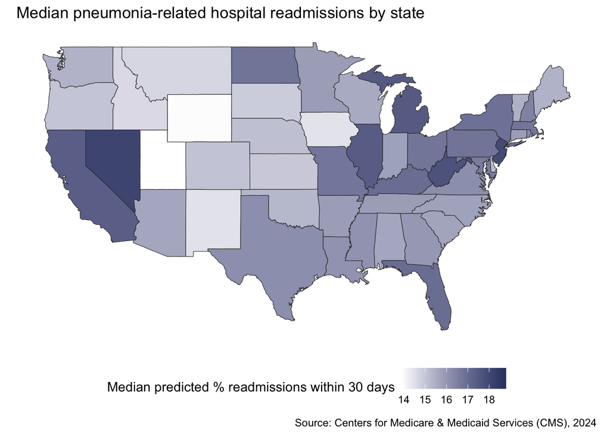

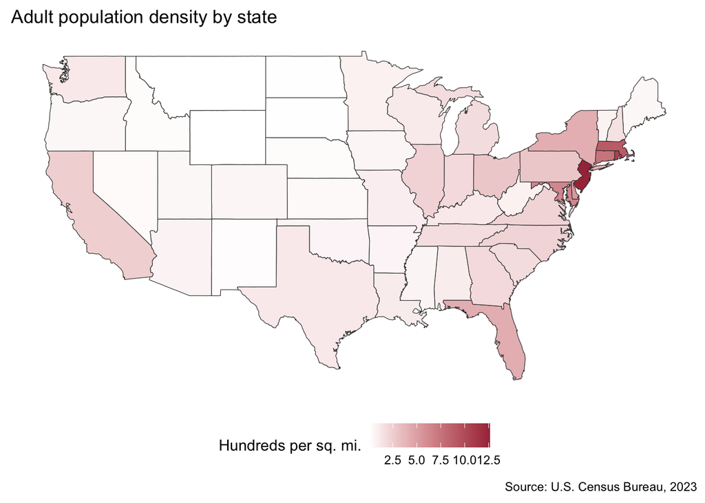

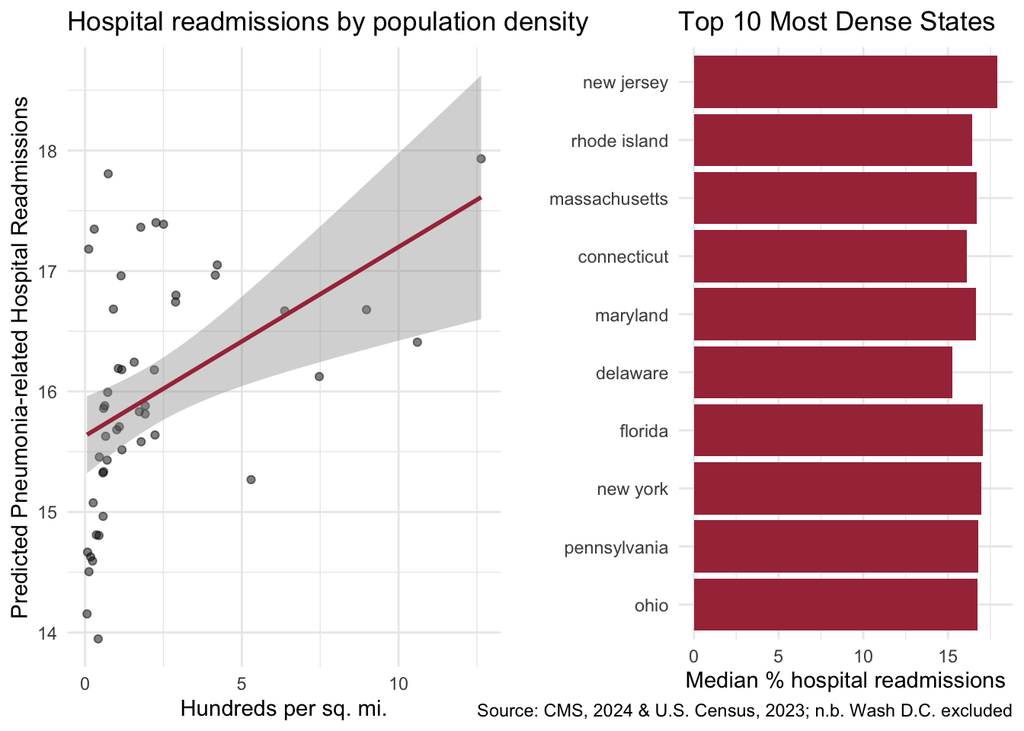

```r
## Make a map `p2` of population density:
p2 <- states_sf_AggTrain %>%
## Remove DC because its extreme density is an outlier that would distort the color scale
  filter(ID != "district of columbia") %>%  ## <- Comment this out to see why!
## Start the ggplot using the sf (spatial) data so we can draw state polygons
ggplot() +
  ## Draw each state's polygon, filling its color by population density
  geom_sf(aes(fill = popDensity), color = "grey20", alpha = 1, size = 0.2) +
  ## Set a white-to-color gradient for the fill, with grey for any missing (NA) states
  scale_fill_gradient(
    name = "Hundreds per sq. mi.",
    low = "white", high = skittles[3],
    na.value = "grey90"
  ) +
  ## Add the title and data source caption
  labs(title = "Adult population density by state",
    caption = "Source: U.S. Census Bureau, 2023") +
  ## Strip out gridlines, axes, and ticks for a clean map look; put legend at the bottom
  theme(
    panel.grid = element_blank(),
    panel.background = element_rect(fill = "white"),
    plot.background = element_rect(fill = "white"),
    axis.text = element_blank(),
    axis.ticks = element_blank(),
    axis.title = element_blank(),
    legend.position = "bottom"
  ) +
  ## Use the correct spatial coordinate system / aspect ratio for the sf map
  coord_sf()

## Make a scatterplot called `p3` with best-fit reference line between
## population density and the pneumonia-related hospital readmissions

p3 <- states_sf_AggTrain %>%
## Remove DC again so its outlier density doesn't drag the regression line
  filter(ID != "district of columbia") %>%  ## <- Comment this out to see why!
## Start the plot mapping density to x and median readmissions to y
ggplot(aes(x = popDensity, y = Median_RawPredictedReadmissionRate)) +
## Plot each state as a semi-transparent point, then add a linear best-fit line with confidence band
  geom_point(alpha = 0.5) +
  geom_smooth(method = "lm", se = T, color = skittles[3]) +
  theme_minimal() +
  ## Add title and axis labels
  labs(title = "Hospital readmissions by population density",
       x = "Hundreds per sq. mi.",
       y = "Predicted Pneumonia-related Hospital Readmissions")

## Make a barplot `p4` that shows the highest density states with their median
p4 <- states_sf_AggTrain %>%
## Remove DC so it doesn't dominate the "densest states" ranking
  filter(ID != "district of columbia") %>%  ## <- Comment this out to see why!
  ## Sort states from highest to lowest population density
  arrange(desc(popDensity)) %>%
  ## Keep only the top 10 densest states
  head(10) %>%
  ## Start the plot; reorder states by density so the bars are sorted, x = state, y = median readmissions
ggplot(aes(x = fct_reorder(ID, popDensity), y = Median_RawPredictedReadmissionRate)) +
  ## Draw the bars (one per state) colored with the skittles palette
  geom_col(fill = skittles[3]) +
  theme_minimal() +
  ## Flip to horizontal bars so state names are readable
  coord_flip() +
  ## Add title, axis labels, and source caption (noting DC was excluded)
  labs(title = "Top 10 Most Dense States",
     y = "Median % hospital readmissions",
     x = "",
     caption = "Source: CMS, 2024 & U.S. Census, 2023; n.b. Wash D.C. excluded")
```

#### **Question 27A**: [0.5 points]

Compare the new map, `p2` of population density to the original map, `p1`. It may be hard to tell at first, but do you see a correlation between population density and median pneumonia-related admissions?

#### **Question 27B**: [0.5 points]

Now look at the scatterplot, `p3`, and the column graph, `p4`. What conclusions can you make, if any, from these two graphs and why?

### 3.2.2 Adding Population Density to the SAR

Now, we can also calculate the spatial statistics using the updated dataset now that we’ve add population density. Let’s make a new `sarTrain` and `sarTest` so we can repeat the spatial regressions we did in Part 2.

#### 3.2.2.1 Make the updated `sarTrain` and `sarTest`

```r
## TRAINING
            ## Start from the training data
sarTrain <- states_sf_AggTrain %>%
  ## Make it a dataframe/tibble
  as_data_frame() %>%
  ## Drop the features that we dropped before the analysis in Project 1, as
  ## well as the features we do NOT want to use as predictors!
  select(-Median_RawPredictedReadmissionRate,
         -Median_RawMedicareSpending,
         -Median_RawHospitalReturnDays,
         -Median_RawDeathRate,
         -ID,
         -localI,
         -pValue,
         -quadrant,
         -geom,
         -lag_medianReadmissions,
  ## Make sure to remove any correlated variables/variables we don't want to
  ## test from the Census data!!
         -totalPop,
         -adultPop,
         -over65Pop,
         -percBelowPoverty,
         -landSqMi,
         -over65PercentPop)

## TESTING
            ## Start from the testing data
sarTest <- states_sf_AggTest %>%
  ## Make it a dataframe/tibble
  as_data_frame() %>%
  ## Move the ID column to the rownames
  column_to_rownames("ID") %>%
  ## Drop the features that we dropped before the analysis in Project 1, as
  ## well as the features we do NOT want to use as predictors!
  select(-Median_RawPredictedReadmissionRate,
         -Median_RawMedicareSpending,
         -Median_RawHospitalReturnDays,
         -Median_RawDeathRate,
         -geom,
         ## Make sure to remove any correlated variables/variables we don't want to
         ## test from the Census data!!
         -totalPop,
         -adultPop,
         -over65Pop,
         -percBelowPoverty,
         -landSqMi,
         -over65PercentPop) %>%
  ## Have to drop any missing values from the testing data
  drop_na()
```

#### **Question 28**: [3 points]

We are about to walk through the spatial regressions again now that we have added `popDensity` to the dataset. You will need to answer an interpretation question after **each** code chunk!

#### 3.2.2.2 Fit the OLS regression and test Moran’s I on the residuals

```r
OLS <- lm(bc_PredictedReadmissionRate ~ ., data = sarTrain)
## Moran's I test on residuals
moran.test(residuals(OLS), states_sw)
```

```
##
##  Moran I test under randomisation
##
## data:  residuals(OLS)
## weights: states_sw
##
## Moran I statistic standard deviate = 1.2912, p-value = 0.09832
## alternative hypothesis: greater
## sample estimates:
## Moran I statistic       Expectation          Variance
##        0.10453179       -0.02083333        0.00942720
```

**QUESTION**: What does Moran’s $I$ test on the residuals tell us about spatial autocorrelation of the residual (error) terms?

**Answer:** The Moran’s I on the OLS residuals is 0.105 with a p-value of 0.098. Because p > 0.05, there is no statistically significant spatial autocorrelation in the residual (error) terms — the leftover errors appear spatially random. This is an improvement over the OLS before we added population density (where the residual Moran’s I was 0.129, p = 0.061): adding popDensity reduced the residual spatial autocorrelation and moved the p-value further from significance, which suggests density absorbed some of the spatial structure that had previously been left in the residuals.

#### 3.2.2.3 Fit the SAR and look at $\rho$ and the LM test

```r
## SAR (spatial lag model)
SAR <- lagsarlm(bc_PredictedReadmissionRate ~ ., data = sarTrain,
                listw = states_sw)
## Uncomment to view results!
summary(SAR)
```

```
##
## Call:lagsarlm(formula = bc_PredictedReadmissionRate ~ ., data = sarTrain,
##     listw = states_sw)
##
## Residuals:
##        Min         1Q     Median         3Q        Max
## -0.5485252 -0.2280885  0.0078934  0.1806131  0.6826910
##
## Type: lag
## Coefficients: (asymptotic standard errors)
##                                                                 Estimate
## (Intercept)                                                   -0.0767219
## MRSA.Bacteremia                                               -0.0528671
## Abdomen.CT.Use.of.Contrast.Material                           -0.0067513
## Death.rate.for.pneumonia.patients                             -0.0389353
## Postoperative.respiratory.failure.rate                        -0.6229064
## Perioperative.pulmonary.embolism.or.deep.vein.thrombosis.rate  0.8092097
## Composite.patient.safety                                      -0.3584346
## Medicare.spending.per.patient                                  0.5284643
## Healthcare.workers.given.influenza.vaccination                -0.0060959
## Left.before.being.seen                                        -0.0698625
## Venous.Thromboembolism.Prophylaxis                            -0.1266912
## Doctor.communication                                           0.2548785
## Communication.about.medicines                                 -0.1214764
## Discharge.information                                         -0.1837904
## Cleanliness                                                   -0.3603474
## Quietness                                                     -0.3206796
## Hospital.return.days.for.pneumonia.patients                    0.2304177
## popDensity                                                     0.0091564
##                                                               Std. Error
## (Intercept)                                                    0.0876569
## MRSA.Bacteremia                                                0.2411199
## Abdomen.CT.Use.of.Contrast.Material                            0.1567272
## Death.rate.for.pneumonia.patients                              0.1950750
## Postoperative.respiratory.failure.rate                         0.3407801
## Perioperative.pulmonary.embolism.or.deep.vein.thrombosis.rate  0.2722906
## Composite.patient.safety                                       0.2085470
## Medicare.spending.per.patient                                  0.1431774
## Healthcare.workers.given.influenza.vaccination                 0.1132179
## Left.before.being.seen                                         0.1496479
```

[output cut: 25 more lines]

```
## Hospital.return.days.for.pneumonia.patients                    1.6008 0.1094214
## popDensity                                                     2.0380 0.0415450
##
## Rho: 0.35443, LR test value: 5.7081, p-value: 0.016887
## Asymptotic standard error: 0.13153
##     z-value: 2.6946, p-value: 0.0070471
## Wald statistic: 7.2609, p-value: 0.0070471
##
## Log likelihood: -10.75671 for lag model
## ML residual variance (sigma squared): 0.087935, (sigma: 0.29654)
## Number of observations: 49
## Number of parameters estimated: 20
## AIC: 61.513, (AIC for lm: 65.221)
## LM test for residual autocorrelation
## test value: 0.16512, p-value: 0.68448
```

**QUESTION**: What is the value of $\rho$ and its $p$-value? Does it suggest that we have spatial dependence in our target variable still? Are you surprised? What about the LM test?

**Answer:** rho value is 0.354 with a p-value of 0.0070, so it’s still significant. The LM test is 0.165 with p = 0.684 (not significant), so there’s no leftover residual spatial autocorrelation — the SAR with density is still sufficient, and we don’t need an SEM or SDM.

#### 3.2.2.4 Compare the SAR to the OLS model with a Likelihood Ratio Test (LRT)

```r
## Give it the larger model first, then the null model.
## SAR is our larger model; the null OLS is nested within the SAR because
## the SAR = OLS when rho = 0!
anova(SAR, OLS)
```

```
##     Model df    AIC  logLik Test L.Ratio  p-value
## SAR     1 20 61.513 -10.757    1
## OLS     2 19 65.221 -13.611    2  5.7081 0.016887
```

**QUESTION**: Which model is the better fitting model and why?

#### 3.2.2.5 Inferential statistics

```r
## Print a table using gtsummary
tbl_regression(SAR) %>%
  modify_caption("Table 7. Spatial Lag (SAR) Regression results.") %>%
  modify_header(label = "**Coefficient**") %>%
  add_significance_stars(hide_p = FALSE)
```

Table 7. Spatial Lag (SAR) Regression results.

| **Coefficient** | **Beta**<sup>1</sup> | **SE** | **p-value** |
| --- | --- | --- | --- |
| rho | 0.35** | 0.132 | 0.007 |
| (Intercept) | -0.08 | 0.088 | 0.4 |
| MRSA.Bacteremia | -0.05 | 0.241 | 0.8 |
| Abdomen.CT.Use.of.Contrast.Material | -0.01 | 0.157 | >0.9 |
| Death.rate.for.pneumonia.patients | -0.04 | 0.195 | 0.8 |
| Postoperative.respiratory.failure.rate | -0.62 | 0.341 | 0.068 |
| Perioperative.pulmonary.embolism.or.deep.vein.thrombosis.rate | 0.81** | 0.272 | 0.003 |
| Composite.patient.safety | -0.36 | 0.209 | 0.086 |
| Medicare.spending.per.patient | 0.53*** | 0.143 | <0.001 |
| Healthcare.workers.given.influenza.vaccination | -0.01 | 0.113 | >0.9 |
| Left.before.being.seen | -0.07 | 0.150 | 0.6 |
| Venous.Thromboembolism.Prophylaxis | -0.13 | 0.222 | 0.6 |
| Doctor.communication | 0.25 | 0.208 | 0.2 |
| Communication.about.medicines | -0.12 | 0.242 | 0.6 |
| Discharge.information | -0.18 | 0.186 | 0.3 |
| Cleanliness | -0.36 | 0.199 | 0.070 |
| Quietness | -0.32** | 0.124 | 0.009 |
| Hospital.return.days.for.pneumonia.patients | 0.23 | 0.144 | 0.11 |
| popDensity | 0.01* | 0.004 | 0.042 |

Abbreviations: CI = Confidence Interval, SE = Standard Error  
<sup>1</sup> *p<0.05; **p<0.01; ***p<0.001

**QUESTION**: Did any of the predictors change significance from the first SAR we ran? What about `popDensity`? Is it significant, and how do you interpret its beta coefficient (the slope) AFTER adjusting for spatial dependence in readmission rate?

**Answer:** No predictor changed its significance status. Yes. popDensity has p = 0.042 β = 0.0092, which is below 0.05 (one star).So population density is a statistically significant predictor of readmissions.

#### 3.2.2.6 Fit SEM and SDM

```r
## Fit the SEM (spatial error model) using the training data and weights matrix
SEM <- errorsarlm(bc_PredictedReadmissionRate ~ ., data = sarTrain,
                  listw = states_sw)
## Uncomment to view results!
## summary(SEM)

## Fit the SDM (spatial Durbin model) using the training data and weights matrix
SDM <- lagsarlm(formula = bc_PredictedReadmissionRate ~ ., data = sarTrain,
    listw = states_sw, type = "mixed") ## "mixed" is necessary to specify as SDM
## Uncomment to view results!
## summary(SDM)
```

#### 3.2.2.6 Predictions using the testing data on SAR, SEM, and SDM

```r
## Fit the predictions for the FOUR models using the testing data!
olsPredictions <- predict(OLS, newdata = sarTest)

sarPredictions <- predict(SAR, newdata = sarTest, listw = states_sw) %>%
  as_tibble()

semPredictions <- predict(SAR, newdata = sarTest, listw = states_sw) %>%
  as_tibble()

sdmPredictions <- predict(SAR, newdata = sarTest, listw = states_sw) %>%
  as_tibble()
```

#### 3.2.2.7 Calculate the $RMSE$ and $MAE$ and compare

```r
## RMSE
olsRMSE <- sqrt(mean((sarTest$bc_PredictedReadmissionRate - olsPredictions)^2))
sarRMSE <- sqrt(mean((sarTest$bc_PredictedReadmissionRate - sarPredictions$fit)^2))
semRMSE <- sqrt(mean((sarTest$bc_PredictedReadmissionRate - semPredictions$fit)^2))
sdmRMSE <- sqrt(mean((sarTest$bc_PredictedReadmissionRate - sdmPredictions$fit)^2))

## MAE
olsMAE <- mean(abs(sarTest$bc_PredictedReadmissionRate - olsPredictions))
sarMAE <- mean(abs(sarTest$bc_PredictedReadmissionRate - sarPredictions$fit))
semMAE <- mean(abs(sarTest$bc_PredictedReadmissionRate - semPredictions$fit))
sdmMAE <- mean(abs(sarTest$bc_PredictedReadmissionRate - sdmPredictions$fit))

## Make a dataframe for comparison of RMSE and MAE values
data.frame(Model = c("OLS", "SAR (Spatial Lag)", "SEM (Spatial Error)", "SDM (Durbin)"),
           RMSE = round(c(olsRMSE, sarRMSE, semRMSE, sdmRMSE), 2),
           MAE = round(c(olsMAE, sarMAE, semMAE, sdmMAE),2)) %>%
  ## Display with kable
  kable(digits = 2,
        format = "html",
        caption = "Table 13. Comparison of RMSE and MAE for all models.") %>%
  kable_styling(bootstrap_options = c("hover", full_width = F)
  )
```

Table 13. Comparison of RMSE and MAE for all models.

| Model | RMSE | MAE |
| --- | --- | --- |
| OLS | 1.30 | 0.82 |
| SAR (Spatial Lag) | 1.09 | 0.74 |
| SEM (Spatial Error) | 1.09 | 0.74 |
| SDM (Durbin) | 1.09 | 0.74 |

**QUESTION**: What does the comparison of the four models’ $RMSE$ and $MAE$ imply? Which model is the superior model? Is SAR still “good enough”? Do you think that, despite adding population density, we’re likely STILL omitting spatial variables? Explain.

## 3.3 Testing Another Hypothesis: Readmissions by ?

The time has finally come for you to choose your own adventure again! There are two more hypotheses we could test using spatially-influenced, social determinants of health (SDOH) that we imported with population density from the U.S. Census.

#### **Question 29**: [10 points]

Choose ONE of the two hypotheses to explore and, using the code from Section 3.2, walk through both the heuristic and spatial regression tests of your chosen hypothesis. The hypotheses have been provided for you this time.

- **Hypothesis 2: High Elderly Populations**: States with a higher proportion of their adult population over the age of 65 have higher rates of readmission **because** of age-related factors that increase the likelihood of severe illness, like pneumonia, and increased risk of complications that could lead to higher hospital readmissions.

But these are not the only population-related hypotheses we could pose. Perhaps, instead, it has to do with poverty - perhaps states with higher poverty rates also tend to see lower rates of medical coverage, thereby leading hospitals to release patients too early to spare costs. Thus, we might also ask if states with higher poverty rates are more likely to see higher pneumonia readmissions?

- **Hypothesis 3: High Poverty Populations**: Higher rates of pneumonia-related readmissions may be associated with higher proportions of the poverty living at or below the poverty threshold **because** those individuals may have poorer medical coverage, including non- and under-insuredness, or a stronger drive to try to return to work, both of which could in turn pressure some hospitals to discharge sick patients sooner than they otherwise would.

**For full credit**, walk through all of the steps from Section 3.2. Make sure to answer the interpretation questions, too!

## Whole Workflow – Hypothesis 2: High Elderly Populations

Hypothesis 2 (High Elderly Populations): States with a higher proportion of adults over age 65 have higher pneumonia readmission rates, because age-related factors increase the likelihood of severe illness and complications that lead to readmission.

```r
names(states_sf_AggTrain)
```

```
##  [1] "ID"
##  [2] "MRSA.Bacteremia"
##  [3] "Abdomen.CT.Use.of.Contrast.Material"
##  [4] "Death.rate.for.pneumonia.patients"
##  [5] "Postoperative.respiratory.failure.rate"
##  [6] "Perioperative.pulmonary.embolism.or.deep.vein.thrombosis.rate"
##  [7] "Composite.patient.safety"
##  [8] "Medicare.spending.per.patient"
##  [9] "Healthcare.workers.given.influenza.vaccination"
## [10] "Left.before.being.seen"
## [11] "Venous.Thromboembolism.Prophylaxis"
## [12] "Doctor.communication"
## [13] "Communication.about.medicines"
## [14] "Discharge.information"
## [15] "Cleanliness"
```

[output cut: 19 more lines]

### 3.3.1 The three heuristic plots

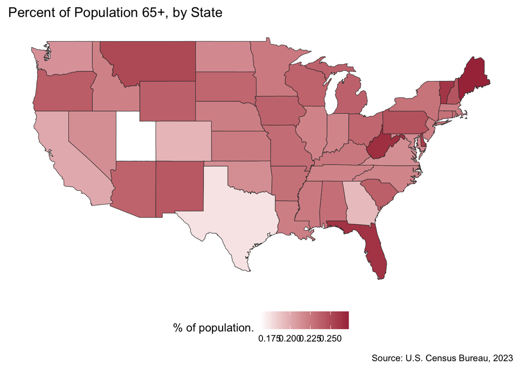

```r
#using variable over65PercentPop

## Make a map `p2` of population percent elderly population (over 65 yrs):
p2 <- states_sf_AggTrain %>%
  filter(ID != "district of columbia") %>%
ggplot() +
  geom_sf(aes(fill = over65PercentPop), color = "grey20", alpha = 1, size = 0.2) +
  scale_fill_gradient(
    name = "% of population.",
    low = "white", high = skittles[3],
    na.value = "grey90"
  ) +
  labs(title = "Percent of Population 65+, by State",
    caption = "Source: U.S. Census Bureau, 2023") +
  theme(
    panel.grid = element_blank(),
    panel.background = element_rect(fill = "white"),
    plot.background = element_rect(fill = "white"),
    axis.text = element_blank(),
    axis.ticks = element_blank(),
    axis.title = element_blank(),
    legend.position = "bottom"
  ) +
  coord_sf()

## Make a scatterplot called `p3` with best-fit reference line between
## Percent of population over the age of 65, and the pneumonia-related hospital readmissions

p3 <- states_sf_AggTrain %>%
  filter(ID != "district of columbia") %>%
ggplot(aes(x = over65PercentPop, y = Median_RawPredictedReadmissionRate)) +
  geom_point(alpha = 0.5) +
  geom_smooth(method = "lm", se = T, color = skittles[3]) +
  theme_minimal() +
  labs(title = "Hospital readmissions by % of population 65+",
       x = "% of population",
       y = "Predicted Pneumonia-related Hospital Readmissions")

## Make a barplot `p4` that shows the highest % opp 65+ with their median
p4 <- states_sf_AggTrain %>%
  filter(ID != "district of columbia") %>%
  arrange(desc(over65PercentPop)) %>%
  head(10) %>%
ggplot(aes(x = fct_reorder(ID, over65PercentPop), y = Median_RawPredictedReadmissionRate)) +
  geom_col(fill = skittles[3]) +
  theme_minimal() +
  coord_flip() +
  labs(title = "Top 10 States with Highest % of Pop 65+",
     y = "Median % hospital readmissions",
     x = "",
     caption = "Source: CMS, 2024 & U.S. Census, 2023; n.b. Wash D.C. excluded")

p2
```

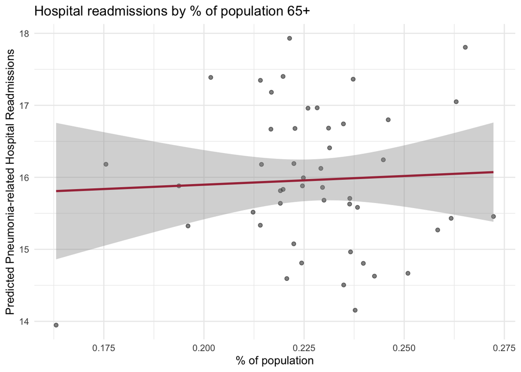

```r
p3
```

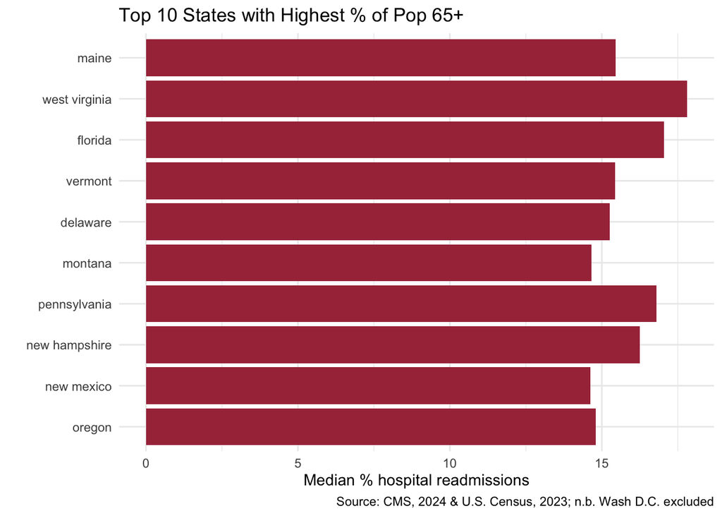

```r
p4
```

### 3.3.2 rebuild sarTrain with the elderly variable, refit OLS, and test Moran’s I on the residuals.

```r
## TRAINING
## Start from the training data
sarTrain <- states_sf_AggTrain %>%
  ## Make it a dataframe/tibble
  as_data_frame() %>%
  ## Drop the features that we dropped before the analysis in Project 1, as
  ## well as the features we do NOT want to use as predictors!
  select(-Median_RawPredictedReadmissionRate,
         -Median_RawMedicareSpending,
         -Median_RawHospitalReturnDays,
         -Median_RawDeathRate,
         -ID,
         -localI,
         -pValue,
         -quadrant,
         -geom,
         -lag_medianReadmissions,
  ## Make sure to remove any correlated variables/variables we don't want to
  ## test from the Census data!!
         -popDensity,
         -totalPop,
         -adultPop,
         -over65Pop,
         -percBelowPoverty,
         -landSqMi)

## TESTING
  ## Start from the testing data
sarTest <- states_sf_AggTest %>%
  ## Make it a dataframe/tibble
  as_data_frame() %>%
  ## Move the ID column to the rownames
  column_to_rownames("ID") %>%
  ## Drop the features that we dropped before the analysis in Project 1, as
  ## well as the features we do NOT want to use as predictors!
  select(-Median_RawPredictedReadmissionRate,
         -Median_RawMedicareSpending,
         -Median_RawHospitalReturnDays,
         -Median_RawDeathRate,
         -geom,
         ## Make sure to remove any correlated variables/variables we don't want to
         ## test from the Census data!!
         -popDensity,
         -totalPop,
         -adultPop,
         -over65Pop,
         -percBelowPoverty,
         -landSqMi) %>%
  ## Have to drop any missing values from the testing data
  drop_na()
```

### 3.3.3 Fit the OLS regression

```r
OLS <- lm(bc_PredictedReadmissionRate ~ ., data = sarTrain)
## Moran's I test on residuals
moran.test(residuals(OLS), states_sw)
```

```
##
##  Moran I test under randomisation
##
## data:  residuals(OLS)
## weights: states_sw
##
## Moran I statistic standard deviate = 1.5815, p-value = 0.05688
## alternative hypothesis: greater
## sample estimates:
## Moran I statistic       Expectation          Variance
##       0.132540584      -0.020833333       0.009405215
```

### 3.3.4 Fit the SAR

```r
## SAR (spatial lag model)
SAR <- lagsarlm(bc_PredictedReadmissionRate ~ ., data = sarTrain,
                listw = states_sw)
summary(SAR)
```

```
##
## Call:lagsarlm(formula = bc_PredictedReadmissionRate ~ ., data = sarTrain,
##     listw = states_sw)
##
## Residuals:
##         Min          1Q      Median          3Q         Max
## -0.64235152 -0.22483126  0.00090686  0.16937740  0.72117364
##
## Type: lag
## Coefficients: (asymptotic standard errors)
##                                                                 Estimate
## (Intercept)                                                    0.5121028
## MRSA.Bacteremia                                               -0.0343097
## Abdomen.CT.Use.of.Contrast.Material                           -0.0217936
## Death.rate.for.pneumonia.patients                             -0.0823365
## Postoperative.respiratory.failure.rate                        -0.6055932
## Perioperative.pulmonary.embolism.or.deep.vein.thrombosis.rate  0.9462358
## Composite.patient.safety                                      -0.3417309
## Medicare.spending.per.patient                                  0.4773302
## Healthcare.workers.given.influenza.vaccination                 0.0346112
## Left.before.being.seen                                        -0.0030515
## Venous.Thromboembolism.Prophylaxis                            -0.1341350
## Doctor.communication                                           0.3760804
## Communication.about.medicines                                 -0.2087982
## Discharge.information                                         -0.2700228
## Cleanliness                                                   -0.3367435
## Quietness                                                     -0.3288389
## Hospital.return.days.for.pneumonia.patients                    0.1260897
## over65PercentPop                                              -2.2547638
##                                                               Std. Error
## (Intercept)                                                    0.6341337
## MRSA.Bacteremia                                                0.2708418
## Abdomen.CT.Use.of.Contrast.Material                            0.1623636
## Death.rate.for.pneumonia.patients                              0.2017153
## Postoperative.respiratory.failure.rate                         0.3568328
## Perioperative.pulmonary.embolism.or.deep.vein.thrombosis.rate  0.2706946
## Composite.patient.safety                                       0.2209597
## Medicare.spending.per.patient                                  0.1465484
## Healthcare.workers.given.influenza.vaccination                 0.1153324
## Left.before.being.seen                                         0.1522869
```

[output cut: 25 more lines]

```
## Hospital.return.days.for.pneumonia.patients                    0.9157 0.359843
## over65PercentPop                                              -0.7989 0.424360
##
## Rho: 0.36237, LR test value: 5.3676, p-value: 0.020514
## Asymptotic standard error: 0.13224
##     z-value: 2.7403, p-value: 0.0061381
## Wald statistic: 7.5093, p-value: 0.0061381
##
## Log likelihood: -12.44762 for lag model
## ML residual variance (sigma squared): 0.09407, (sigma: 0.30671)
## Number of observations: 49
## Number of parameters estimated: 20
## AIC: 64.895, (AIC for lm: 68.263)
## LM test for residual autocorrelation
## test value: 0.083488, p-value: 0.77262
```

### 3.3.5 Compare the OLS and SAR

```r
## Give it the larger model first, then the null model.
## SAR is our larger model; the null OLS is nested within the SAR because
## the SAR = OLS when rho = 0!
anova(SAR, OLS)
```

```
##     Model df    AIC  logLik Test L.Ratio  p-value
## SAR     1 20 64.895 -12.448    1
## OLS     2 19 68.263 -15.131    2  5.3676 0.020514
```

### 3.3.6 Inferential statistics

```r
## Print a table using gtsummary
tbl_regression(SAR) %>%
  modify_caption("Table 7. Spatial Lag (SAR) Regression results.") %>%
  modify_header(label = "**Coefficient**") %>%
  add_significance_stars(hide_p = FALSE)
```

Table 7. Spatial Lag (SAR) Regression results.

| **Coefficient** | **Beta**<sup>1</sup> | **SE** | **p-value** |
| --- | --- | --- | --- |
| rho | 0.36** | 0.132 | 0.006 |
| (Intercept) | 0.51 | 0.634 | 0.4 |
| MRSA.Bacteremia | -0.03 | 0.271 | 0.9 |
| Abdomen.CT.Use.of.Contrast.Material | -0.02 | 0.162 | 0.9 |
| Death.rate.for.pneumonia.patients | -0.08 | 0.202 | 0.7 |
| Postoperative.respiratory.failure.rate | -0.61 | 0.357 | 0.090 |
| Perioperative.pulmonary.embolism.or.deep.vein.thrombosis.rate | 0.95*** | 0.271 | <0.001 |
| Composite.patient.safety | -0.34 | 0.221 | 0.12 |
| Medicare.spending.per.patient | 0.48** | 0.147 | 0.001 |
| Healthcare.workers.given.influenza.vaccination | 0.03 | 0.115 | 0.8 |
| Left.before.being.seen | 0.00 | 0.152 | >0.9 |
| Venous.Thromboembolism.Prophylaxis | -0.13 | 0.231 | 0.6 |
| Doctor.communication | 0.38 | 0.204 | 0.066 |
| Communication.about.medicines | -0.21 | 0.247 | 0.4 |
| Discharge.information | -0.27 | 0.187 | 0.15 |
| Cleanliness | -0.34 | 0.223 | 0.13 |
| Quietness | -0.33* | 0.134 | 0.014 |
| Hospital.return.days.for.pneumonia.patients | 0.13 | 0.138 | 0.4 |
| over65PercentPop | -2.3 | 2.82 | 0.4 |

Abbreviations: CI = Confidence Interval, SE = Standard Error  
<sup>1</sup> *p<0.05; **p<0.01; ***p<0.001

### 3.3.7 Fit SEM and SDM

```r
## Fit the SEM (spatial error model) using the training data and weights matrix
SEM <- errorsarlm(bc_PredictedReadmissionRate ~ ., data = sarTrain,
                  listw = states_sw)
## Uncomment to view results!
summary(SEM)
```

```
##
## Call:errorsarlm(formula = bc_PredictedReadmissionRate ~ ., data = sarTrain,
##     listw = states_sw)
##
## Residuals:
##       Min        1Q    Median        3Q       Max
## -0.585055 -0.194859  0.018292  0.121578  0.680268
##
## Type: error
## Coefficients: (asymptotic standard errors)
##                                                                Estimate
## (Intercept)                                                    0.772244
## MRSA.Bacteremia                                               -0.071155
## Abdomen.CT.Use.of.Contrast.Material                           -0.064583
## Death.rate.for.pneumonia.patients                             -0.237358
## Postoperative.respiratory.failure.rate                        -0.268447
## Perioperative.pulmonary.embolism.or.deep.vein.thrombosis.rate  0.617849
## Composite.patient.safety                                      -0.246179
## Medicare.spending.per.patient                                  0.476871
## Healthcare.workers.given.influenza.vaccination                -0.037378
## Left.before.being.seen                                         0.103677
## Venous.Thromboembolism.Prophylaxis                            -0.228181
## Doctor.communication                                           0.365410
## Communication.about.medicines                                 -0.017224
## Discharge.information                                         -0.532432
## Cleanliness                                                   -0.241674
## Quietness                                                     -0.213093
## Hospital.return.days.for.pneumonia.patients                    0.166227
## over65PercentPop                                              -3.386780
##                                                               Std. Error
## (Intercept)                                                     0.638299
## MRSA.Bacteremia                                                 0.251571
## Abdomen.CT.Use.of.Contrast.Material                             0.144614
## Death.rate.for.pneumonia.patients                               0.200038
## Postoperative.respiratory.failure.rate                          0.300372
## Perioperative.pulmonary.embolism.or.deep.vein.thrombosis.rate   0.261173
## Composite.patient.safety                                        0.208534
## Medicare.spending.per.patient                                   0.140069
## Healthcare.workers.given.influenza.vaccination                  0.121467
## Left.before.being.seen                                          0.135230
```

[output cut: 23 more lines]

```
## Cleanliness                                                   -1.1634 0.2446554
## Quietness                                                     -1.3007 0.1933778
## Hospital.return.days.for.pneumonia.patients                    1.0873 0.2769003
## over65PercentPop                                              -1.2229 0.2213750
##
## Lambda: 0.67036, LR test value: 7.2511, p-value: 0.0070859
## Asymptotic standard error: 0.1117
##     z-value: 6.0012, p-value: 0.0000000019585
## Wald statistic: 36.015, p-value: 0.0000000019585
##
## Log likelihood: -11.50591 for error model
## ML residual variance (sigma squared): 0.081535, (sigma: 0.28554)
## Number of observations: 49
## Number of parameters estimated: 20
## AIC: 63.012, (AIC for lm: 68.263)
```

```r
## Fit the SDM (spatial Durbin model) using the training data and weights matrix
SDM <- lagsarlm(formula = bc_PredictedReadmissionRate ~ ., data = sarTrain,
    listw = states_sw, type = "mixed") ## "mixed" is necessary to specify as SDM
## Uncomment to view results!
summary(SDM)
```

```
##
## Call:lagsarlm(formula = bc_PredictedReadmissionRate ~ ., data = sarTrain,
##     listw = states_sw, type = "mixed")
##
## Residuals:
##        Min         1Q     Median         3Q        Max
## -0.4460452 -0.0904562  0.0016838  0.1238609  0.4442171
##
## Type: mixed
## Coefficients: (asymptotic standard errors)
##                                                                    Estimate
## (Intercept)                                                       -4.028423
## MRSA.Bacteremia                                                    0.020072
## Abdomen.CT.Use.of.Contrast.Material                               -0.027374
## Death.rate.for.pneumonia.patients                                  0.200054
## Postoperative.respiratory.failure.rate                            -1.460475
## Perioperative.pulmonary.embolism.or.deep.vein.thrombosis.rate      1.528842
## Composite.patient.safety                                          -0.377545
## Medicare.spending.per.patient                                      0.822824
## Healthcare.workers.given.influenza.vaccination                     0.070747
## Left.before.being.seen                                             0.057472
## Venous.Thromboembolism.Prophylaxis                                 0.298025
## Doctor.communication                                               0.307391
## Communication.about.medicines                                      0.395960
## Discharge.information                                             -0.657053
## Cleanliness                                                       -0.350438
## Quietness                                                         -0.241547
## Hospital.return.days.for.pneumonia.patients                        0.081602
## over65PercentPop                                                   2.358304
## lag.MRSA.Bacteremia                                                1.426352
## lag.Abdomen.CT.Use.of.Contrast.Material                           -0.086783
## lag.Death.rate.for.pneumonia.patients                              0.817956
## lag.Postoperative.respiratory.failure.rate                        -3.058096
## lag.Perioperative.pulmonary.embolism.or.deep.vein.thrombosis.rate  2.255736
## lag.Composite.patient.safety                                       0.415998
## lag.Medicare.spending.per.patient                                  0.914592
## lag.Healthcare.workers.given.influenza.vaccination                 0.041143
## lag.Left.before.being.seen                                        -0.280496
## lag.Venous.Thromboembolism.Prophylaxis                             1.832981
## lag.Doctor.communication                                          -1.073727
```

[output cut: 112 more lines]

```
## lag.Hospital.return.days.for.pneumonia.patients                          0.2243924
## lag.over65PercentPop                                                     0.0516503
##
## Rho: -0.32804, LR test value: 1.8058, p-value: 0.17901
## Asymptotic standard error: 0.17923
##     z-value: -1.8303, p-value: 0.067206
## Wald statistic: 3.35, p-value: 0.067206
##
## Log likelihood: 16.62563 for mixed model
## ML residual variance (sigma squared): 0.029, (sigma: 0.1703)
## Number of observations: 49
## Number of parameters estimated: 37
## AIC: 40.749, (AIC for lm: 40.555)
## LM test for residual autocorrelation
## test value: 9.7575, p-value: 0.001786
```

### 3.3.8 Predictions using the testing data on SAR , SDM and SEM

```r
## Fit the predictions for the FOUR models using the testing data!
olsPredictions <- predict(OLS, newdata = sarTest)

sarPredictions <- predict(SAR, newdata = sarTest, listw = states_sw) %>%
  as_tibble()

semPredictions <- predict(SAR, newdata = sarTest, listw = states_sw) %>%
  as_tibble()

sdmPredictions <- predict(SAR, newdata = sarTest, listw = states_sw) %>%
  as_tibble()
```

### 3.3.9 Calculate the RMSE and MAE

```r
## RMSE
olsRMSE <- sqrt(mean((sarTest$bc_PredictedReadmissionRate - olsPredictions)^2))
sarRMSE <- sqrt(mean((sarTest$bc_PredictedReadmissionRate - sarPredictions$fit)^2))
semRMSE <- sqrt(mean((sarTest$bc_PredictedReadmissionRate - semPredictions$fit)^2))
sdmRMSE <- sqrt(mean((sarTest$bc_PredictedReadmissionRate - sdmPredictions$fit)^2))

## MAE
olsMAE <- mean(abs(sarTest$bc_PredictedReadmissionRate - olsPredictions))
sarMAE <- mean(abs(sarTest$bc_PredictedReadmissionRate - sarPredictions$fit))
semMAE <- mean(abs(sarTest$bc_PredictedReadmissionRate - semPredictions$fit))
sdmMAE <- mean(abs(sarTest$bc_PredictedReadmissionRate - sdmPredictions$fit))

## Make a dataframe for comparison of RMSE and MAE values
data.frame(Model = c("OLS", "SAR (Spatial Lag)", "SEM (Spatial Error)", "SDM (Durbin)"),
           RMSE = round(c(olsRMSE, sarRMSE, semRMSE, sdmRMSE), 2),
           MAE = round(c(olsMAE, sarMAE, semMAE, sdmMAE),2)) %>%
  ## Display with kable
  kable(digits = 2,
        format = "html",
        caption = "Table 13. Comparison of RMSE and MAE for all models.") %>%
  kable_styling(bootstrap_options = c("hover", full_width = F)
  )
```

Table 13. Comparison of RMSE and MAE for all models.

| Model | RMSE | MAE |
| --- | --- | --- |
| OLS | 1.33 | 0.85 |
| SAR (Spatial Lag) | 1.13 | 0.79 |
| SEM (Spatial Error) | 1.13 | 0.79 |
| SDM (Durbin) | 1.13 | 0.79 |

### 3.3.10 Conclusion

Hypothesis 2: The evidence doesn’t support it. The scatterplot was basically flat, and the top-10 elderly states had readmissions all over the place (~14.5% to ~17.5%) rather than uniformly high. The SAR confirmed it: over65PercentPop wasn’t significant (β = −2.25, p = 0.42), and the coefficient was even negative.

Unlike population density, elderly proportion isn’t a useful predictor here, and Hypothesis 2 isn’t supported.